# ANOVA,MANOVA, and Posthoc

Chiyu Ma

12/19/2020

# Loading packages

```r
library("readxl")
library("ggplot2")
library('tidyverse')
library("grid")
library('gridExtra')
library("ggpubr")
library("rstatix")
library("stats")
library("pander")
library("lme4")
```

```r
my_theme <- theme_bw()+
  theme(plot.title = element_text(hjust=0.5),
        axis.text.x = element_text(size=11),
        axis.text.y = element_text(size = 11,angle=45),
        axis.title = element_text(size = 13),
        plot.subtitle   = element_text(color="coral",hjust=0.5)
)
```

This chunk is used to set up the theme for the visualizations

# Loading the data, and data correction

```r
data <- read_xls("Woodley data ready for R V2.xls")
data$pesticide[which(data$pesticide == "Salt L")]="Water"
data$pesticide[which(data$pesticide == "Salt H")]="Water"
data$pesticide[which(data$combo=="Control")]= "Water"
data$salt[which(data$combo == "Chlor H")]="N"
data$salt[which(data$combo == "Chlor L")]="N"
```

1. We first change the Salt L and Salt High in pesticide category to water
2. We change pesticide that shows control in the combo column to water
3. We change the salt level labeled on Chlor H and Chlor L to N so that it matches the combo column
4. By doing the above correction, we will have a similar setting as the one described in the Introduction Power point.

# EDA

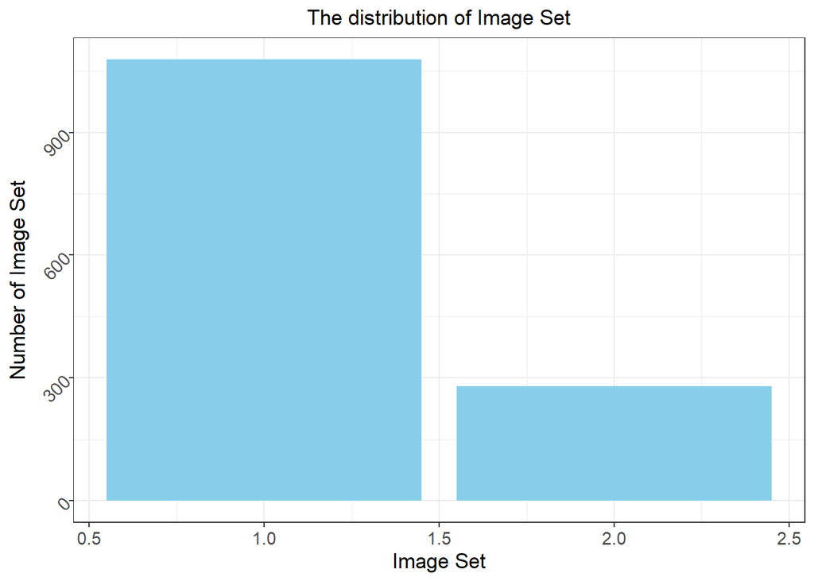

```r
 ggplot(data,aes(imageset))+
  geom_bar(fill="skyblue")+
  labs(x="Image Set",y="Number of Image Set",
       title = "The distribution of Image Set")+
  my_theme
```

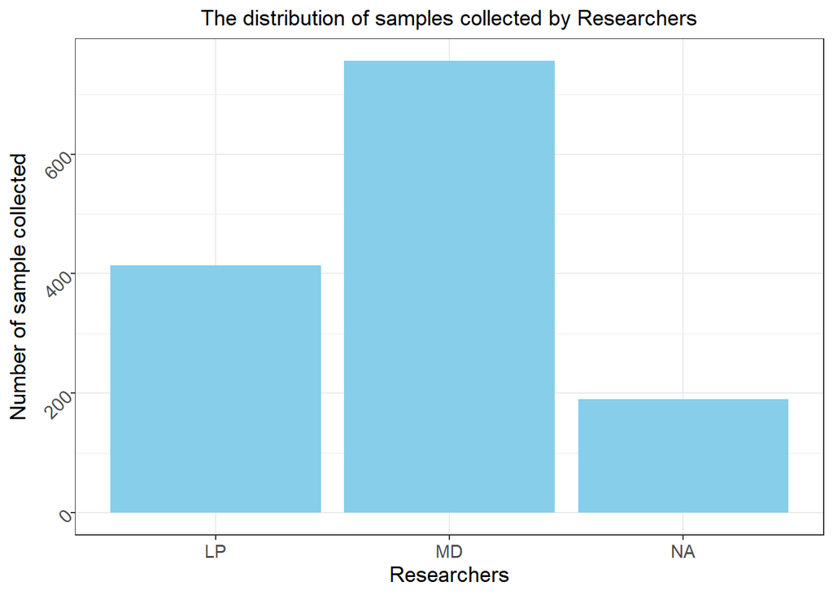

```r
ggplot(data,aes(person))+
  geom_bar(fill="skyblue")+
  labs(x="Researchers",y="Number of sample collected",
       title = "The distribution of samples collected by Researchers")+
  my_theme
```

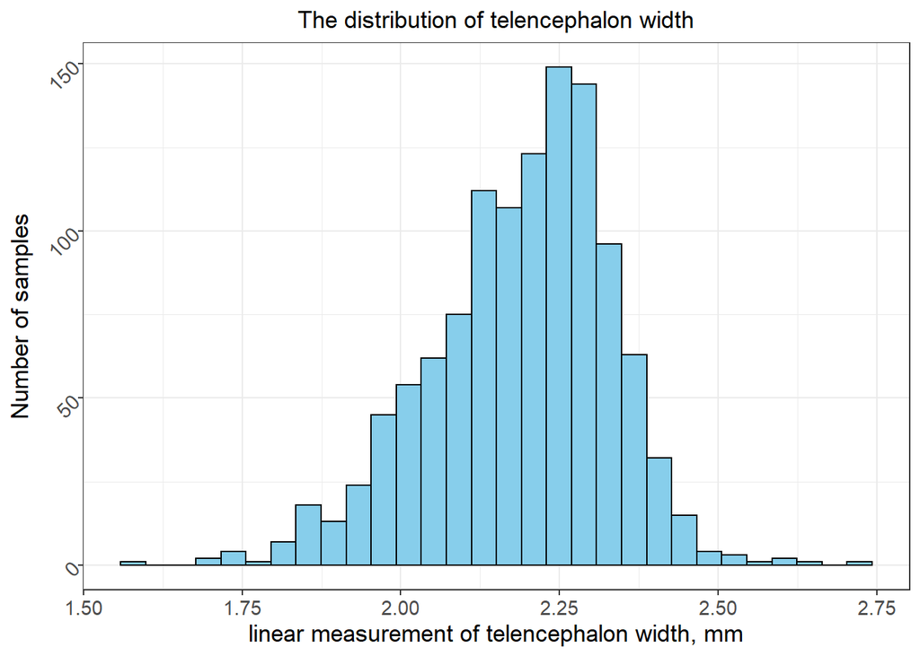

```r
ggplot(data,aes(tw))+
  geom_histogram(fill="skyblue",bins = 30,col="black")+
  labs(x="linear measurement of telencephalon width, mm",y="Number of samples",
       title = "The distribution of telencephalon width")+
  my_theme
```

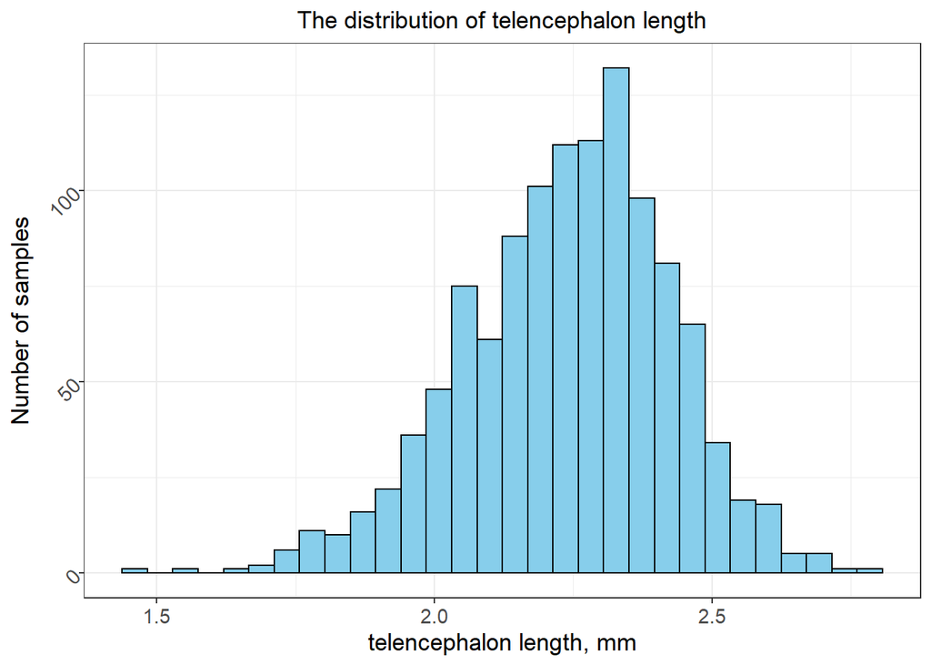

```r
ggplot(data,aes(tl))+
  geom_histogram(fill="skyblue",bins = 30,col="black")+
  labs(x="telencephalon length, mm",y="Number of samples",
       title = "The distribution of telencephalon length")+
  my_theme
```

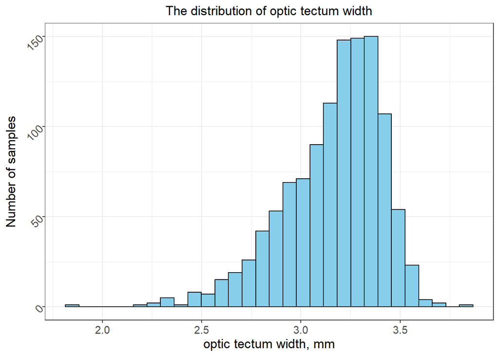

```r
 ggplot(data,aes(otw))+
  geom_histogram(fill="skyblue",bins = 30,col="black")+
  labs(x="optic tectum width, mm",y="Number of samples",
       title = "The distribution of optic tectum width")+
  my_theme
```

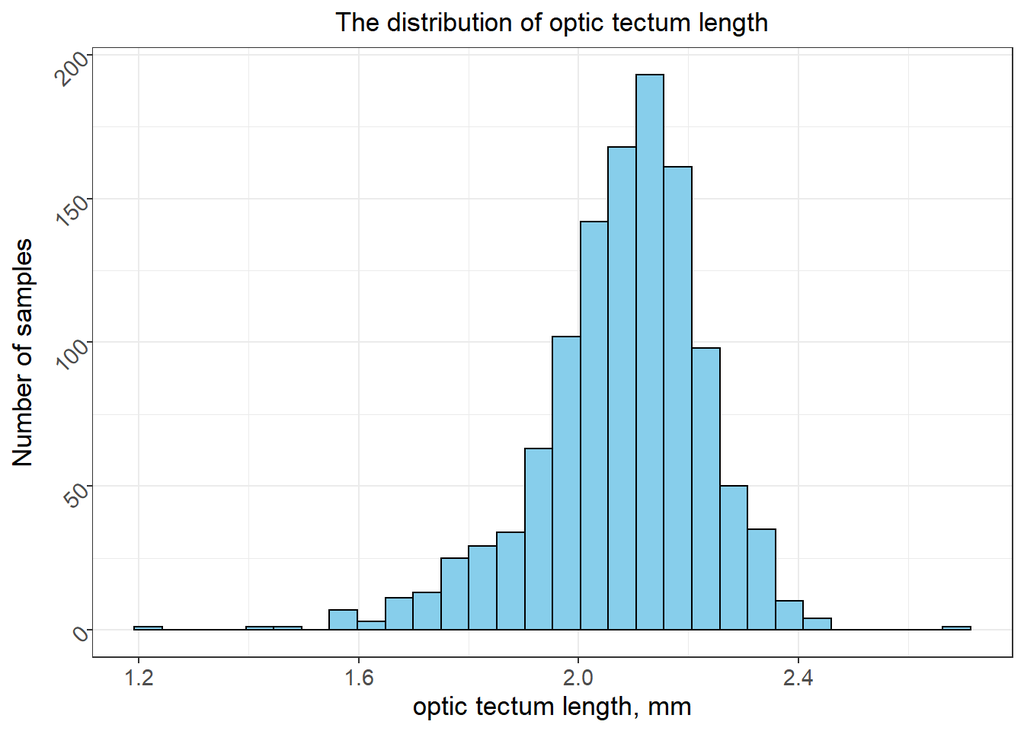

```r
 ggplot(data,aes(otl))+
  geom_histogram(fill="skyblue",bins = 30,col="black")+
  labs(x="optic tectum length, mm",y="Number of samples",
       title = "The distribution of optic tectum length")+
  my_theme
```

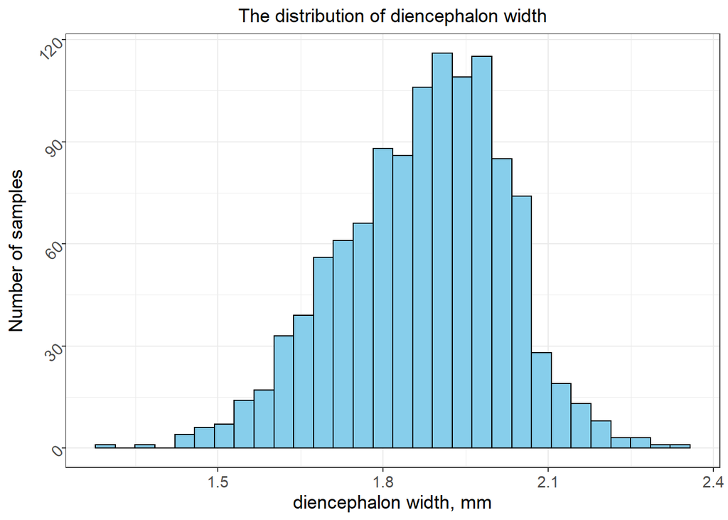

```r
 ggplot(data,aes(dw))+
  geom_histogram(fill="skyblue",bins = 30,col="black")+
  labs(x="diencephalon width, mm",y="Number of samples",
       title = "The distribution of diencephalon width")+
  my_theme
```

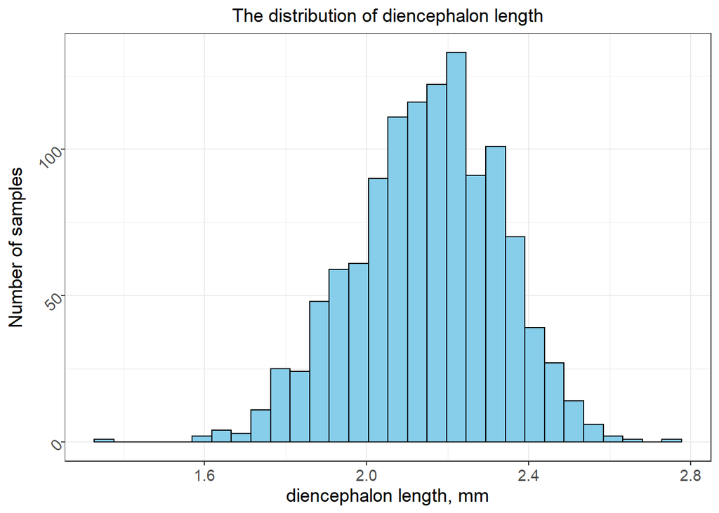

```r
 ggplot(data,aes(dl))+
  geom_histogram(fill="skyblue",bins = 30,col="black")+
  labs(x="diencephalon length, mm",y="Number of samples",
       title = "The distribution of diencephalon length")+
  my_theme
```

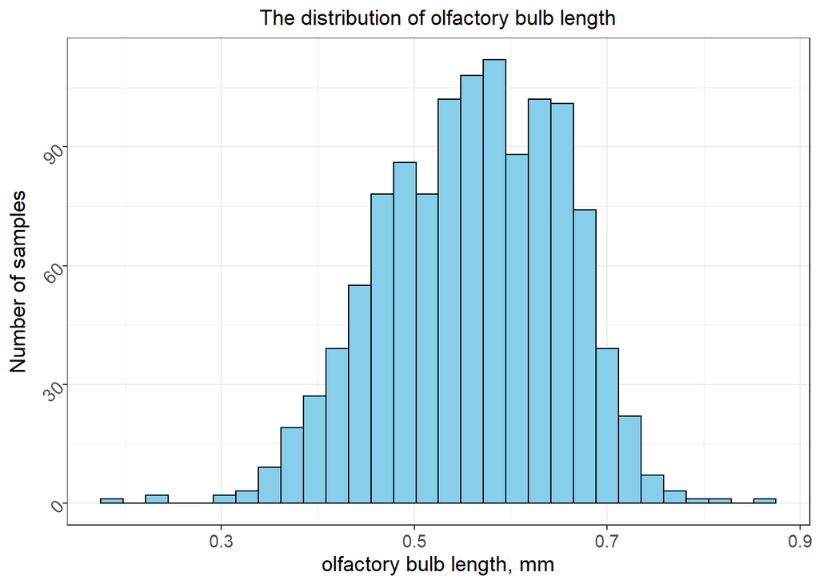

```r
 ggplot(data,aes(obl))+
  geom_histogram(fill="skyblue",bins = 30,col="black")+
  labs(x="olfactory bulb length, mm",y="Number of samples",
       title = "The distribution of olfactory bulb length")+
  my_theme
```

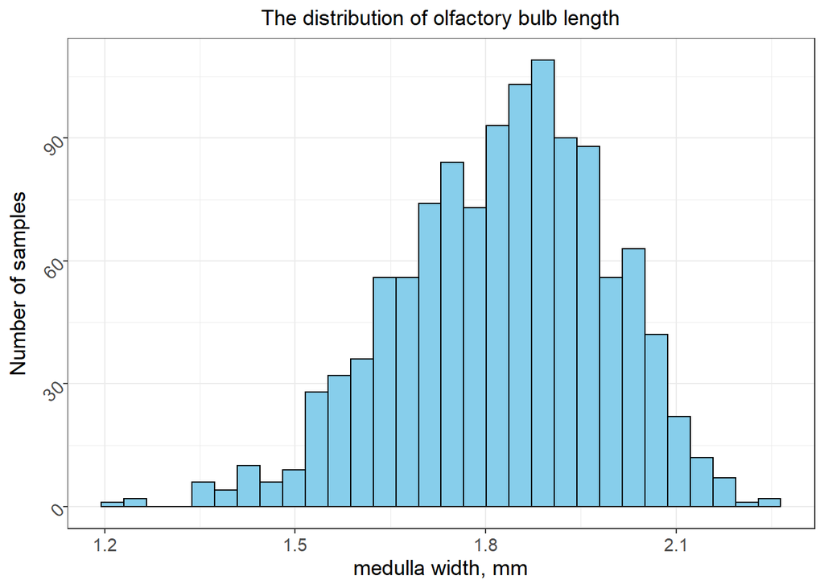

```r
  ggplot(data,aes(mw))+
  geom_histogram(fill="skyblue",bins = 30,col="black")+
  labs(x="medulla width, mm",y="Number of samples",
       title = "The distribution of olfactory bulb length")+
  my_theme
```

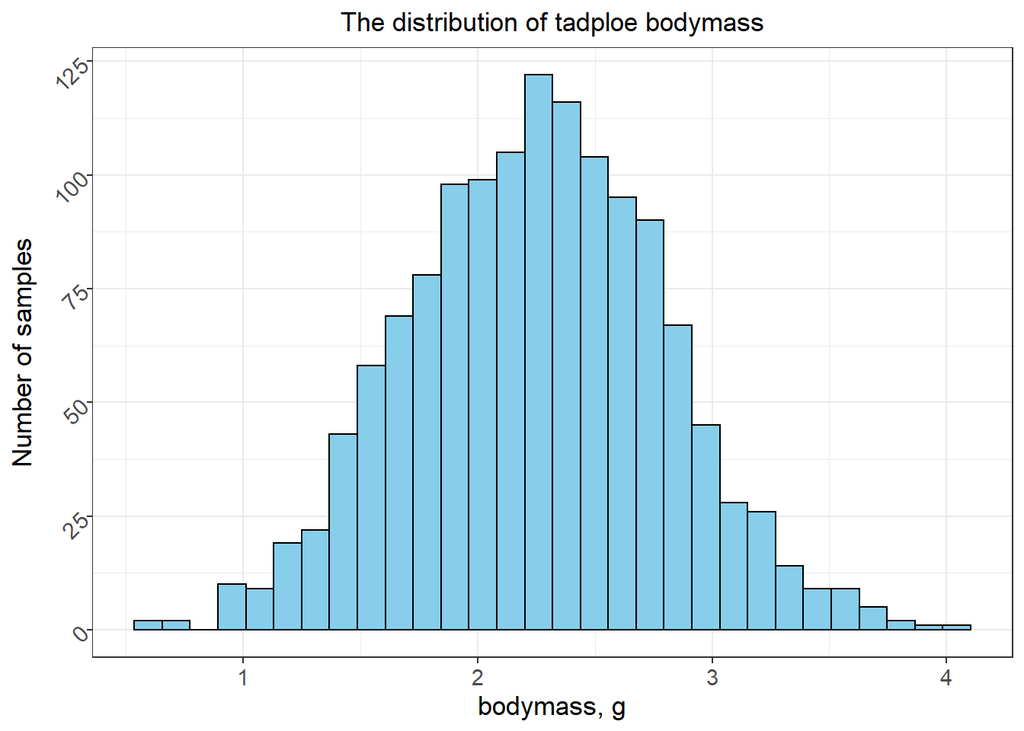

```r
  ggplot(data,aes(bodymass))+
  geom_histogram(fill="skyblue",bins = 30,col="black")+
  labs(x="bodymass, g",y="Number of samples",
       title = "The distribution of tadploe bodymass")+
  my_theme
```

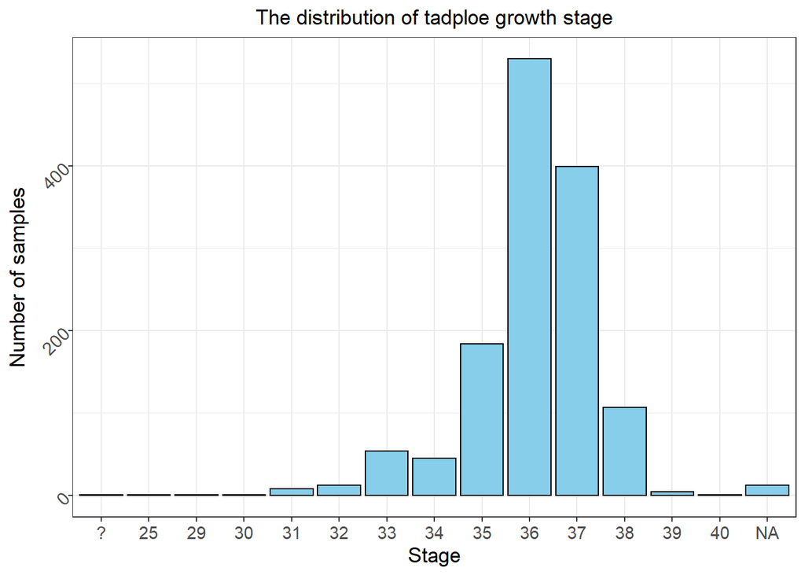

```r
   ggplot(data,aes(stage))+
  geom_histogram(fill="skyblue",bins = 30,col="black",stat = "count")+
  labs(x="Stage",y="Number of samples",
       title = "The distribution of tadploe growth stage")+
  my_theme
```

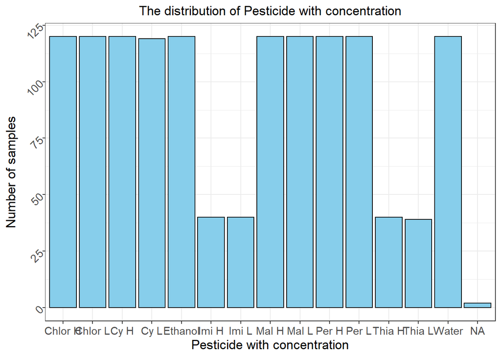

```r
  ggplot(data,aes(pesticide))+
  geom_histogram(fill="skyblue",bins = 30,col="black",stat = "count")+
  labs(x="Pesticide with concentration",y="Number of samples",
       title = "The distribution of Pesticide with concentration")+
  my_theme
```

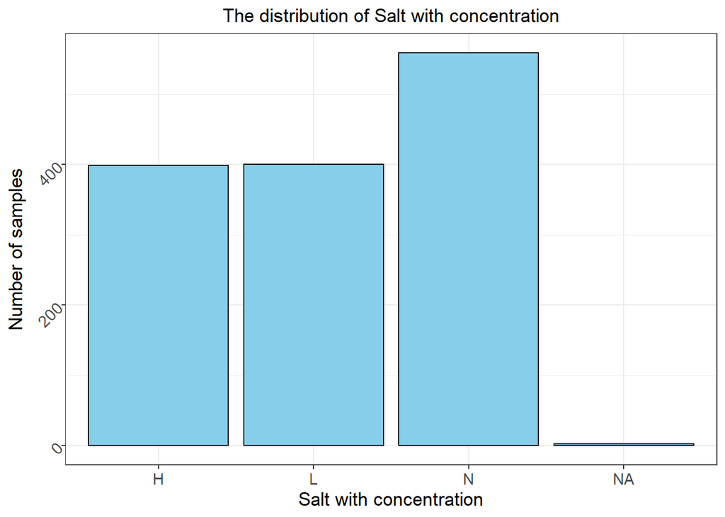

```r
  ggplot(data,aes(salt))+
  geom_histogram(fill="skyblue",bins = 30,col="black",stat = "count")+
  labs(x="Salt with concentration",y="Number of samples",
       title = "The distribution of Salt with concentration")+
  my_theme
```

This chunk plots the distribution of all the variables except combo

```r
table(data$combo)
```

```
##
##        Chlor H Chlor H/Salt H Chlor H/Salt L        Chlor L Chlor L/Salt H
##             40             40             40             40             40
## Chlor L/Salt L        Control           Cy H    Cy H/Salt H    Cy H/Salt L
##             40             40             40             40             40
##           Cy L    Cy L/Salt H    Cy L/Salt L        Ethanol Ethanol/Salt H
##             40             39             40             40             40
## Ethanol/Salt L          Imi H          Imi L          Mal H   Mal H/Salt H
##             40             40             40             40             40
##   Mal H/Salt L          Mal L   Mal L/Salt H   Mal L/Salt L          Per H
##             40             40             40             40             40
##   Per H/Salt H   Per H/Salt L          Per L   Per L/Salt H   Per L/Salt L
##             40             40             40             40             40
##         Salt H         Salt L         Thia H         Thia L
##             40             40             40             39
```

combo variable is displayed in a table format. The setting of the combo is similar to what described in the experiment setting except two missing rows.

One row is missing in experiment 1 and another row is missing in the experiment 2.

# Separating data into experiment 1 and experiment 2

```r
data2 <- data %>% separate(pesticide,
                c("pesticide2", "pesticidecon"), remove = FALSE)

experiment1 <- data2 %>% filter(data2$salt == "N")
experiment2 <- data2 %>% filter(data2$pesticide2 %in% c("Mal", "Chlor", "Cy", "Per", "Ethanol", "Water"))

experiment1$pesticidecon[experiment1$pesticide2 %in% c("Ethanol", "Water")] = NaN
experiment2$pesticidecon[experiment2$pesticide2 %in% c("Ethanol", "Water")] = NaN
```

1. Separate pesticide column into 2 columns. Pesticide 2: Pesticide Category, pesticidecon: Pesticide concentration
2. Set the concentration of ethanol and water as NaN (Undefined)

# Experiment 1

## Two Way ANOVA on Body Mass

```r
experiment1%>%
  anova_test(bodymass~pesticide2 * pesticidecon)
```

```
## ANOVA Table (type II tests)
##
##                    Effect DFn DFd     F     p p<.05   ges
## 1              pesticide2   6 540 2.175 0.044     * 0.024
## 2            pesticidecon   1 540 3.051 0.081       0.006
## 3 pesticide2:pesticidecon   5 540 1.172 0.322       0.011
```

1. Interaction is statistically insignificant
2. Only the pesticide category has statistically significant effect
3. Need to look at the Pesticide effect alone in post-hoc study

### Post-Hoc on Body Mass

```r
test_posthoc_exp1 <-experiment1%>%
  tukey_hsd(bodymass~pesticide2)

test_posthoc_exp1[which(test_posthoc_exp1$p.adj<=0.05),]%>%
  pander()
```

Table continues below

| term | group1 | group2 | estimate | conf.low | conf.high | p.adj |
| --- | --- | --- | --- | --- | --- | --- |
| pesticide2 | Ethanol | Mal | -0.308 | -0.6101 | -0.005787 | 0.0422 |
| pesticide2 | Imi | Mal | -0.2525 | -0.5 | -0.004953 | 0.0418 |

| p.adj.signif |
| --- |
| * |
| * |

This chunk performed Tukey-test on pesticide category in terms of mean body mass. The pairs with p-value <= 0.05 is shown

1. Mal has associated with statistically significant smaller body mass than Imi and Ethanol.

### Visualization for Body Mass

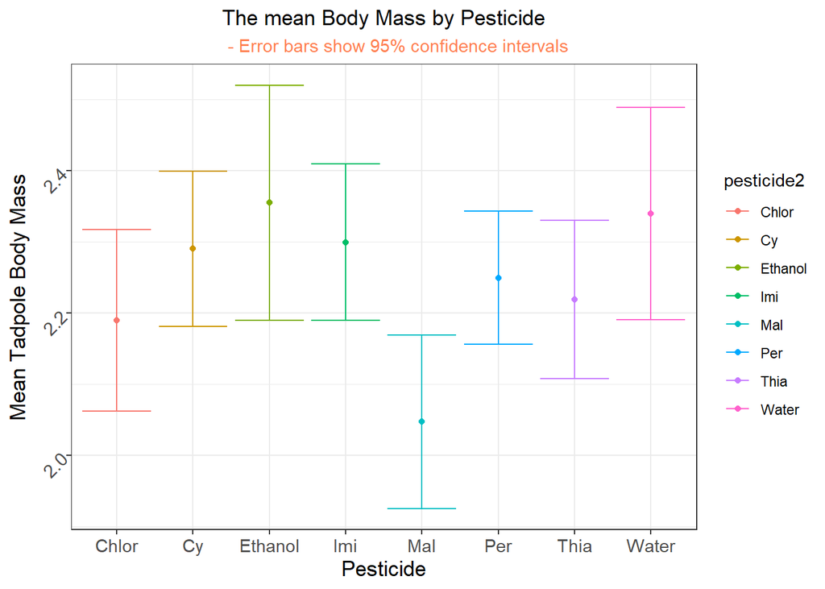

```r
BM_exp1 = experiment1%>%
  group_by(pesticide2)%>%
  summarise(count = n(),  #  calculate count, mean, and sd in each group
             mean = mean(bodymass,na.rm=TRUE),
             std_dev = sd(bodymass,na.rm =TRUE ))%>%
   mutate(std_error = std_dev / sqrt(count),  #  add standard error of each mean
         lower = mean - 1.96 * std_error,  #  compute lower bound
          upper = mean + 1.96 * std_error)

ggplot(BM_exp1,aes(x=pesticide2,y=mean,col=pesticide2))+
  geom_point()+
  geom_errorbar(aes(ymin = lower,
                    ymax=upper))+
  labs(x="Pesticide",
       y="Mean Tadpole Body Mass",
       title = "The mean Body Mass by Pesticide",
       subtitle = "      - Error bars show 95% confidence intervals")+
  my_theme
```

## Experiment 1 MANOVA

```r
manova_test = manova(cbind(tw,tl,dw,dl,otw,otl,obl,mw)~pesticide2 * pesticidecon,data=experiment1)

manova_test%>%pander()
```

Table continues below

|  | Df | Pillai | approx F | num Df | den Df |
| --- | --- | --- | --- | --- | --- |
| **pesticide2** | 7 | 0.5712 | 4.687 | 56 | 2954 |
| **pesticidecon** | 1 | 0.04933 | 2.698 | 8 | 416 |
| **pesticide2:pesticidecon** | 5 | 0.2571 | 2.846 | 40 | 2100 |
| **Residuals** | 423 | NA | NA | NA | NA |

|  | Pr(>F) |
| --- | --- |
| **pesticide2** | 5.716e-27 |
| **pesticidecon** | 0.006649 |
| **pesticide2:pesticidecon** | 1.013e-08 |
| **Residuals** | NA |

This chunk shows the MANOVA result for the 8 dimensions of brain measurements

1. Pesticide category, pesticide Concentration, and Interaction terms all have the significant effect on brain dimensions.
2. Will look at ANOVA test on each brain dimension with Post-hoc Test

### Two way ANOVA for MW

```r
experiment1%>%
  anova_test(mw~pesticide2 * pesticidecon)
```

```
## ANOVA Table (type II tests)
##
##                    Effect DFn DFd     F        p p<.05   ges
## 1              pesticide2   6 438 6.522 1.32e-06     * 0.082
## 2            pesticidecon   1 438 6.325 1.20e-02     * 0.014
## 3 pesticide2:pesticidecon   5 438 4.126 1.00e-03     * 0.045
```

1. Interaction term is statistically significant

#### Post-hoc test for MW

```r
experiment1%>%
  group_by(pesticidecon)%>%
  anova_test(mw~pesticide2)%>%
  pander()
```

| pesticidecon | Effect | DFn | DFd | F | p | p<.05 | ges |
| --- | --- | --- | --- | --- | --- | --- | --- |
| H | pesticide2 | 5 | 191 | 1.397 | 0.227 |  | 0.035 |
| L | pesticide2 | 5 | 193 | 3.948 | 0.002 | * | 0.093 |
| NaN | pesticide2 | 1 | 54 | 41.67 | 3.15e-08 | * | 0.436 |

This chunk performed one way ANOVA of pesticide category in terms of mean mw by each concentration level.

```r
test_posthoc_exp1 <-experiment1%>%
  group_by(pesticidecon)%>%
  tukey_hsd(mw~pesticide2)


test_posthoc_exp1[which(test_posthoc_exp1$p.adj<=0.05),]%>%
  pander()
```

Table continues below

| pesticidecon | term | group1 | group2 | estimate | conf.low | conf.high |
| --- | --- | --- | --- | --- | --- | --- |
| L | pesticide2 | Chlor | Cy | 0.1449 | 0.03706 | 0.2528 |
| L | pesticide2 | Cy | Mal | -0.129 | -0.2362 | -0.02169 |
| L | pesticide2 | Cy | Per | -0.1497 | -0.27 | -0.02941 |
| NaN | pesticide2 | Ethanol | Water | -0.2339 | -0.3065 | -0.1612 |

| p.adj | p.adj.signif |
| --- | --- |
| 0.00206 | ** |
| 0.00857 | ** |
| 0.00568 | ** |
| 3.15e-08 | **** |

This chunk performed Tukey-test on pesticide category in terms of mean MW. The pairs with p-value <= 0.05 are shown

### Visualization for MW

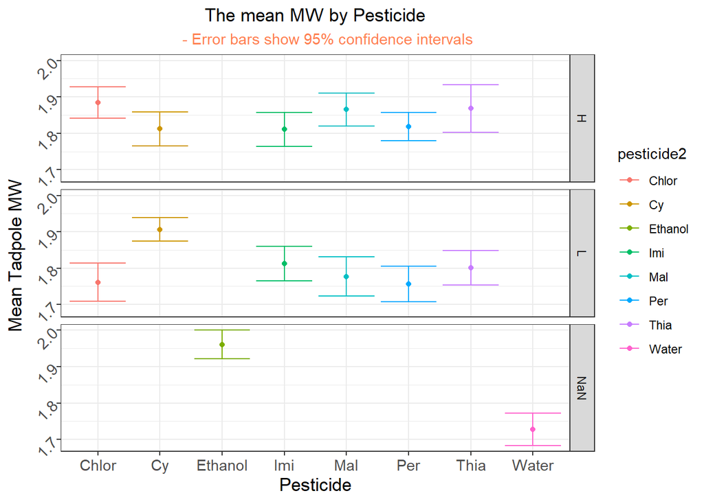

```r
MW_exp1 = experiment1%>%
  group_by(pesticidecon,pesticide2)%>%
  summarise(count = n(),  #  calculate count, mean, and sd in each group
             mean = mean(mw,na.rm=TRUE),
             std_dev = sd(mw,na.rm =TRUE ))%>%
   mutate(std_error = std_dev / sqrt(count),  #  add standard error of each mean
         lower = mean - 1.96 * std_error,  #  compute lower bound
          upper = mean + 1.96 * std_error)


ggplot(MW_exp1,aes(x=pesticide2,y=mean,col=pesticide2))+
  geom_point()+
  geom_errorbar(aes(ymin = lower,
                    ymax=upper))+
  labs(x="Pesticide",
       y="Mean Tadpole MW ",
       title = "The mean MW by Pesticide",
       subtitle = "      - Error bars show 95% confidence intervals")+
  my_theme+
  facet_grid(pesticidecon~.)
```

### Two way ANOVA For TW

```r
experiment1%>%
  anova_test(tw~pesticide2 * pesticidecon)%>%
  pander()
```

| Effect | DFn | DFd | F | p | p<.05 | ges |
| --- | --- | --- | --- | --- | --- | --- |
| pesticide2 | 6 | 436 | 2.968 | 0.008 | * | 0.039 |
| pesticidecon | 1 | 436 | 4.991 | 0.026 | * | 0.011 |
| pesticide2:pesticidecon | 5 | 436 | 2.824 | 0.016 | * | 0.031 |

1. Pesticide, concentration and interactions are statistically significant

#### Post-Hoc for TW

```r
experiment1%>%
  group_by(pesticidecon)%>%
  anova_test(tw~pesticide2)%>%
  pander()
```

| pesticidecon | Effect | DFn | DFd | F | p | p<.05 | ges |
| --- | --- | --- | --- | --- | --- | --- | --- |
| H | pesticide2 | 5 | 190 | 0.918 | 0.47 |  | 0.024 |
| L | pesticide2 | 5 | 192 | 2.628 | 0.025 | * | 0.064 |
| NaN | pesticide2 | 1 | 54 | 16.93 | 0.000133 | * | 0.239 |

```r
test_posthoc_exp1 <-experiment1%>%
  group_by(pesticidecon)%>%
  tukey_hsd(tw~pesticide2)


test_posthoc_exp1[which(test_posthoc_exp1$p.adj<=0.05),]%>%
  pander()
```

Table continues below

| pesticidecon | term | group1 | group2 | estimate | conf.low | conf.high |
| --- | --- | --- | --- | --- | --- | --- |
| L | pesticide2 | Cy | Mal | -0.1063 | -0.2025 | -0.009984 |
| NaN | pesticide2 | Ethanol | Water | -0.1374 | -0.2044 | -0.07047 |

| p.adj | p.adj.signif |
| --- | --- |
| 0.0211 | * |
| 0.000133 | *** |

This chunk performed one way ANOVA of pesticide category in terms of mean TW by each concentration level and a Tukey-test on pesticide category in terms of mean TW. The pairs with p-value <= 0.05 are shown

### Visualization for TW

```r
TW_exp1 = experiment1%>%
  group_by(pesticidecon,pesticide2)%>%
  summarise(count = n(),  #  calculate count, mean, and sd in each group
             mean = mean(tw,na.rm=TRUE),
             std_dev = sd(tw,na.rm =TRUE ))%>%
   mutate(std_error = std_dev / sqrt(count),  #  add standard error of each mean
         lower = mean - 1.96 * std_error,  #  compute lower bound
          upper = mean + 1.96 * std_error)
```

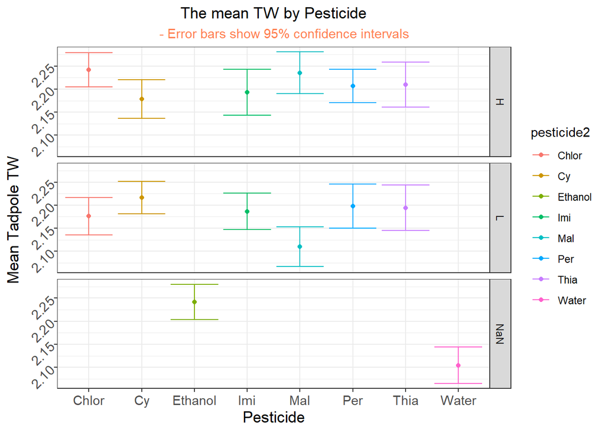

```r
ggplot(TW_exp1,aes(x=pesticide2,y=mean,col=pesticide2))+
  geom_point()+
  geom_errorbar(aes(ymin = lower,
                    ymax=upper))+
  labs(x="Pesticide",
       y="Mean Tadpole TW ",
       title = "The mean TW by Pesticide",
       subtitle = "      - Error bars show 95% confidence intervals")+
  my_theme+
  facet_grid(pesticidecon~.)
```

### Two way ANOVA for TL

```r
experiment1%>%
  anova_test(tl~pesticide2 * pesticidecon)%>%
  pander()
```

| Effect | DFn | DFd | F | p | p<.05 | ges |
| --- | --- | --- | --- | --- | --- | --- |
| pesticide2 | 6 | 438 | 1.647 | 0.133 |  | 0.022 |
| pesticidecon | 1 | 438 | 0.223 | 0.637 |  | 0.000508 |
| pesticide2:pesticidecon | 5 | 438 | 2.46 | 0.033 | * | 0.027 |

1. The interaction term is statistically significant

#### Post-Hoc for TL

```r
experiment1%>%
  group_by(pesticidecon)%>%
  anova_test(tl~pesticide2)%>%
  pander()
```

| pesticidecon | Effect | DFn | DFd | F | p | p<.05 | ges |
| --- | --- | --- | --- | --- | --- | --- | --- |
| H | pesticide2 | 5 | 191 | 0.763 | 0.577 |  | 0.02 |
| L | pesticide2 | 5 | 193 | 3.561 | 0.004 | * | 0.084 |
| NaN | pesticide2 | 1 | 54 | 0.124 | 0.726 |  | 0.002 |

```r
test_posthoc_exp1 <-experiment1%>%
  group_by(pesticidecon)%>%
  tukey_hsd(tl~pesticide2)


test_posthoc_exp1[which(test_posthoc_exp1$p.adj<=0.05),]%>%
  pander()
```

Table continues below

| pesticidecon | term | group1 | group2 | estimate | conf.low | conf.high |
| --- | --- | --- | --- | --- | --- | --- |
| L | pesticide2 | Imi | Mal | -0.1204 | -0.2394 | -0.001479 |
| L | pesticide2 | Mal | Per | 0.1694 | 0.03743 | 0.3014 |

| p.adj | p.adj.signif |
| --- | --- |
| 0.0453 | * |
| 0.00384 | ** |

This chunk performed one way ANOVA of pesticide category in terms of mean TL by each concentration level and a Tukey-test on pesticide category in terms of mean TL. The pairs with p-value <= 0.05 are shown

### Visualization for TL

```r
TL_exp1 = experiment1%>%
  group_by(pesticidecon,pesticide2)%>%
  summarise(count = n(),  #  calculate count, mean, and sd in each group
             mean = mean(tl,na.rm=TRUE),
             std_dev = sd(tl,na.rm =TRUE ))%>%
   mutate(std_error = std_dev / sqrt(count),  #  add standard error of each mean
         lower = mean - 1.96 * std_error,  #  compute lower bound
          upper = mean + 1.96 * std_error)
```

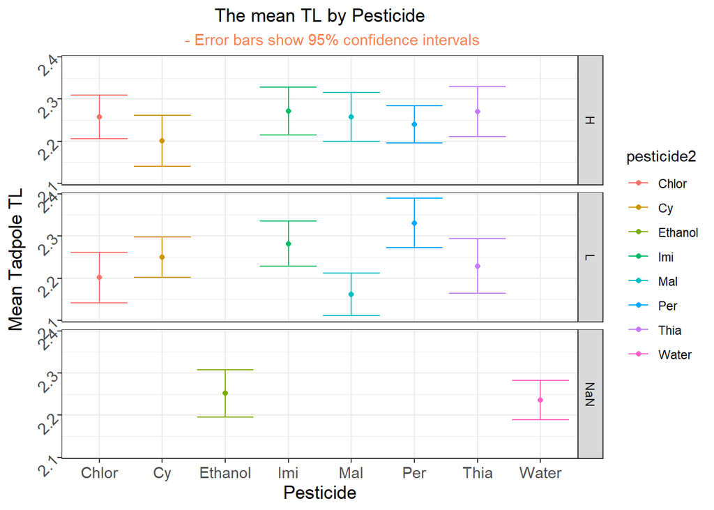

```r
ggplot(TL_exp1,aes(x=pesticide2,y=mean,col=pesticide2))+
  geom_point()+
  geom_errorbar(aes(ymin = lower,
                    ymax=upper))+
  labs(x="Pesticide",
       y="Mean Tadpole TL ",
       title = "The mean TL by Pesticide",
       subtitle = "      - Error bars show 95% confidence intervals")+
  my_theme+
  facet_grid(pesticidecon~.)
```

### Two way ANOVA for OTW

```r
experiment1%>%
  anova_test(otw~pesticide2 * pesticidecon)%>%
  pander()
```

| Effect | DFn | DFd | F | p | p<.05 | ges |
| --- | --- | --- | --- | --- | --- | --- |
| pesticide2 | 6 | 435 | 2.17 | 0.045 | * | 0.029 |
| pesticidecon | 1 | 435 | 5.473 | 0.02 | * | 0.012 |
| pesticide2:pesticidecon | 5 | 435 | 3.074 | 0.01 | * | 0.034 |

1. Pesticide category, concentration and the interaction are statistically significant.

#### Post-Hoc for OTW

```r
experiment1%>%
  group_by(pesticidecon)%>%
  anova_test(otw~pesticide2)%>%
  pander()
```

| pesticidecon | Effect | DFn | DFd | F | p | p<.05 | ges |
| --- | --- | --- | --- | --- | --- | --- | --- |
| H | pesticide2 | 5 | 190 | 1.006 | 0.416 |  | 0.026 |
| L | pesticide2 | 5 | 192 | 2.607 | 0.026 | * | 0.064 |
| NaN | pesticide2 | 1 | 53 | 13.24 | 0.000621 | * | 0.2 |

```r
test_posthoc_exp1 <-experiment1%>%
  group_by(pesticidecon)%>%
  tukey_hsd(otw~pesticide2)


test_posthoc_exp1[which(test_posthoc_exp1$p.adj<=0.05),]%>%
  pander()
```

Table continues below

| pesticidecon | term | group1 | group2 | estimate | conf.low | conf.high |
| --- | --- | --- | --- | --- | --- | --- |
| L | pesticide2 | Cy | Mal | -0.1788 | -0.3471 | -0.01042 |
| NaN | pesticide2 | Ethanol | Water | -0.2006 | -0.3112 | -0.09004 |

| p.adj | p.adj.signif |
| --- | --- |
| 0.0303 | * |
| 0.000621 | *** |

This chunk performed one way ANOVA of pesticide category in terms of mean OTW by each concentration level and a Tukey-test on pesticide category in terms of mean OTW. The pairs with p-value <= 0.05 are shown

### Visualization for OTW

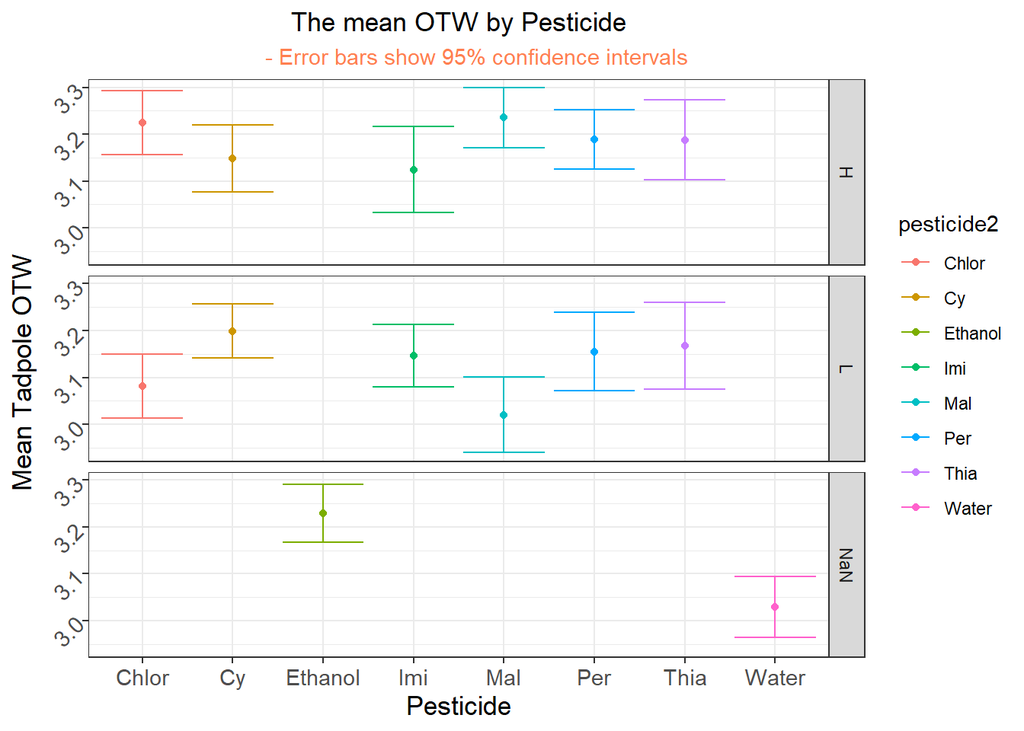

```r
OTW_exp1 = experiment1%>%
  group_by(pesticidecon,pesticide2)%>%
  summarise(count = n(),  #  calculate count, mean, and sd in each group
             mean = mean(otw,na.rm=TRUE),
             std_dev = sd(otw,na.rm =TRUE ))%>%
   mutate(std_error = std_dev / sqrt(count),  #  add standard error of each mean
         lower = mean - 1.96 * std_error,  #  compute lower bound
          upper = mean + 1.96 * std_error)


ggplot(OTW_exp1,aes(x=pesticide2,y=mean,col=pesticide2))+
  geom_point()+
  geom_errorbar(aes(ymin = lower,
                    ymax=upper))+
  labs(x="Pesticide",
       y="Mean Tadpole OTW ",
       title = "The mean OTW by Pesticide",
       subtitle = "      - Error bars show 95% confidence intervals")+
  my_theme+
  facet_grid(pesticidecon~.)
```

### Two way ANOVA for OTL

```r
experiment1%>%
  anova_test(otl~pesticide2 * pesticidecon)%>%
  pander()
```

| Effect | DFn | DFd | F | p | p<.05 | ges |
| --- | --- | --- | --- | --- | --- | --- |
| pesticide2 | 6 | 428 | 0.901 | 0.494 |  | 0.012 |
| pesticidecon | 1 | 428 | 0.59 | 0.443 |  | 0.001 |
| pesticide2:pesticidecon | 5 | 428 | 1.864 | 0.099 |  | 0.021 |

#### Post-hoc for OTL

```r
experiment1%>%
  group_by(pesticidecon)%>%
  anova_test(otl~pesticide2)%>%
  pander()
```

| pesticidecon | Effect | DFn | DFd | F | p | p<.05 | ges |
| --- | --- | --- | --- | --- | --- | --- | --- |
| H | pesticide2 | 5 | 189 | 0.358 | 0.877 |  | 0.009 |
| L | pesticide2 | 5 | 186 | 2.202 | 0.056 |  | 0.056 |
| NaN | pesticide2 | 1 | 53 | 2.121 | 0.151 |  | 0.038 |

```r
test_posthoc_exp1 <-experiment1%>%
  group_by(pesticidecon)%>%
  tukey_hsd(otl~pesticide2)


test_posthoc_exp1[which(test_posthoc_exp1$p.adj<=0.05),]%>%
  pander()
```

Table continues below

| **pesticidecon** | **term** | **group1** | **group2** | **estimate** |
| --- | --- | --- | --- | --- |

| **conf.low** | **conf.high** | **p.adj** | **p.adj.signif** |
| --- | --- | --- | --- |

This chunk performed one way ANOVA of pesticide category in terms of mean OTL by each concentration level and a Tukey-test on pesticide category in terms of mean OTL. The pairs with p-value <= 0.05 are shown

### Visualization for OTL

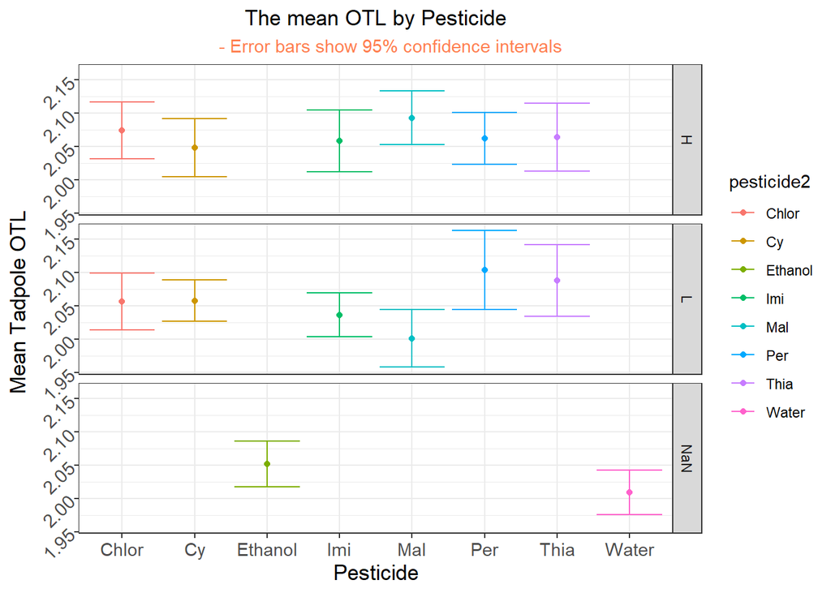

```r
OTL_exp1 = experiment1%>%
  group_by(pesticidecon,pesticide2)%>%
  summarise(count = n(),  #  calculate count, mean, and sd in each group
             mean = mean(otl,na.rm=TRUE),
             std_dev = sd(otl,na.rm =TRUE ))%>%
   mutate(std_error = std_dev / sqrt(count),  #  add standard error of each mean
         lower = mean - 1.96 * std_error,  #  compute lower bound
          upper = mean + 1.96 * std_error)


ggplot(OTL_exp1,aes(x=pesticide2,y=mean,col=pesticide2))+
  geom_point()+
  geom_errorbar(aes(ymin = lower,
                    ymax=upper))+
  labs(x="Pesticide",
       y="Mean Tadpole OTL ",
       title = "The mean OTL by Pesticide",
       subtitle = "      - Error bars show 95% confidence intervals")+
  my_theme+
  facet_grid(pesticidecon~.)
```

### Two way ANOVA for OBL

```r
experiment1%>%
  anova_test(obl~pesticide2 * pesticidecon)%>%
  pander()
```

| Effect | DFn | DFd | F | p | p<.05 | ges |
| --- | --- | --- | --- | --- | --- | --- |
| pesticide2 | 6 | 437 | 4.272 | 0.000339 | * | 0.055 |
| pesticidecon | 1 | 437 | 1.469 | 0.226 |  | 0.003 |
| pesticide2:pesticidecon | 5 | 437 | 6.795 | 4.06e-06 | * | 0.072 |

#### Post-hoc for OBL

```r
experiment1%>%
  group_by(pesticidecon)%>%
  anova_test(obl~pesticide2)%>%
  pander()
```

| pesticidecon | Effect | DFn | DFd | F | p | p<.05 | ges |
| --- | --- | --- | --- | --- | --- | --- | --- |
| H | pesticide2 | 5 | 191 | 1.034 | 0.399 |  | 0.026 |
| L | pesticide2 | 5 | 192 | 10.46 | 6.83e-09 | * | 0.214 |
| NaN | pesticide2 | 1 | 54 | 10.27 | 0.002 | * | 0.16 |

```r
test_posthoc_exp1 <-experiment1%>%
  group_by(pesticidecon)%>%
  tukey_hsd(obl~pesticide2)


test_posthoc_exp1[which(test_posthoc_exp1$p.adj<=0.05),]%>%
  pander()
```

Table continues below

| pesticidecon | term | group1 | group2 | estimate | conf.low | conf.high |
| --- | --- | --- | --- | --- | --- | --- |
| L | pesticide2 | Chlor | Cy | 0.1003 | 0.04255 | 0.158 |
| L | pesticide2 | Chlor | Imi | 0.06211 | 0.007685 | 0.1165 |
| L | pesticide2 | Cy | Mal | -0.08748 | -0.1449 | -0.03005 |
| L | pesticide2 | Cy | Per | -0.125 | -0.1892 | -0.0607 |
| L | pesticide2 | Cy | Thia | -0.1145 | -0.1763 | -0.05264 |
| L | pesticide2 | Imi | Per | -0.08679 | -0.1481 | -0.02548 |
| L | pesticide2 | Imi | Thia | -0.0763 | -0.1351 | -0.01754 |
| NaN | pesticide2 | Ethanol | Water | -0.05789 | -0.09411 | -0.02167 |

| p.adj | p.adj.signif |
| --- | --- |
| 1.89e-05 | **** |
| 0.0151 | * |
| 0.000273 | *** |
| 1.1e-06 | **** |
| 4.07e-06 | **** |
| 0.000941 | *** |
| 0.0033 | ** |
| 0.00227 | ** |

This chunk performed one way ANOVA of pesticide category in terms of mean OBL by each concentration level and a Tukey-test on pesticide category in terms of mean OBL. The pairs with p-value <= 0.05 are shown

### Visualization for OBL

```r
OBL_exp1 = experiment1%>%
  group_by(pesticidecon,pesticide2)%>%
  summarise(count = n(),  #  calculate count, mean, and sd in each group
             mean = mean(obl,na.rm=TRUE),
             std_dev = sd(obl,na.rm =TRUE ))%>%
   mutate(std_error = std_dev / sqrt(count),  #  add standard error of each mean
         lower = mean - 1.96 * std_error,  #  compute lower bound
          upper = mean + 1.96 * std_error)
```

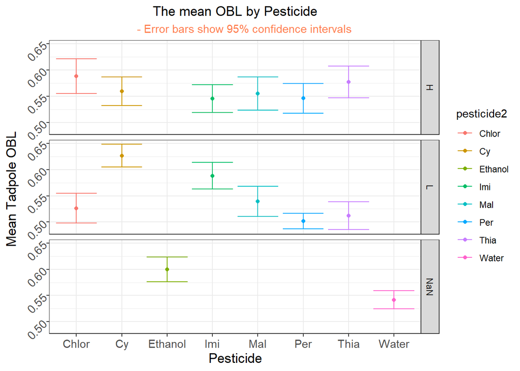

```r
ggplot(OBL_exp1,aes(x=pesticide2,y=mean,col=pesticide2))+
  geom_point()+
  geom_errorbar(aes(ymin = lower,
                    ymax=upper))+
  labs(x="Pesticide",
       y="Mean Tadpole OBL ",
       title = "The mean OBL by Pesticide",
       subtitle = "      - Error bars show 95% confidence intervals")+
  my_theme+
  facet_grid(pesticidecon~.)
```

### Two way ANOVA for DW

```r
experiment1%>%
  anova_test(dw~pesticide2 * pesticidecon)%>%
  pander()
```

| Effect | DFn | DFd | F | p | p<.05 | ges |
| --- | --- | --- | --- | --- | --- | --- |
| pesticide2 | 6 | 434 | 3.956 | 0.000727 | * | 0.052 |
| pesticidecon | 1 | 434 | 5.87 | 0.016 | * | 0.013 |
| pesticide2:pesticidecon | 5 | 434 | 1.994 | 0.078 |  | 0.022 |

1. Interaction term is not statistically significant
2. Only look at the pesticide effect and its concentration
3. The interaction is very close to 0.05, so we still perform a post-hoc test on interaction term for the sake of completeness

#### Post hoc on interaction

```r
experiment1%>%
  group_by(pesticidecon)%>%
  anova_test(dw~pesticide2)%>%
  pander()
```

| pesticidecon | Effect | DFn | DFd | F | p | p<.05 | ges |
| --- | --- | --- | --- | --- | --- | --- | --- |
| H | pesticide2 | 5 | 188 | 1.433 | 0.214 |  | 0.037 |
| L | pesticide2 | 5 | 192 | 1.504 | 0.19 |  | 0.038 |
| NaN | pesticide2 | 1 | 54 | 26.54 | 3.74e-06 | * | 0.33 |

```r
test_posthoc_exp1 <-experiment1%>%
  group_by(pesticidecon)%>%
  tukey_hsd(dw~pesticide2)


test_posthoc_exp1[which(test_posthoc_exp1$p.adj<=0.05),]%>%
  pander()
```

Table continues below

| pesticidecon | term | group1 | group2 | estimate | conf.low | conf.high |
| --- | --- | --- | --- | --- | --- | --- |
| NaN | pesticide2 | Ethanol | Water | -0.1647 | -0.2287 | -0.1006 |

| p.adj | p.adj.signif |
| --- | --- |
| 3.74e-06 | **** |

This chunk performed one way ANOVA of pesticide category in terms of mean DW by each concentration level and a Tukey-test on pesticide category in terms of mean DW. The pairs with p-value <= 0.05 are shown

### visualization interaction

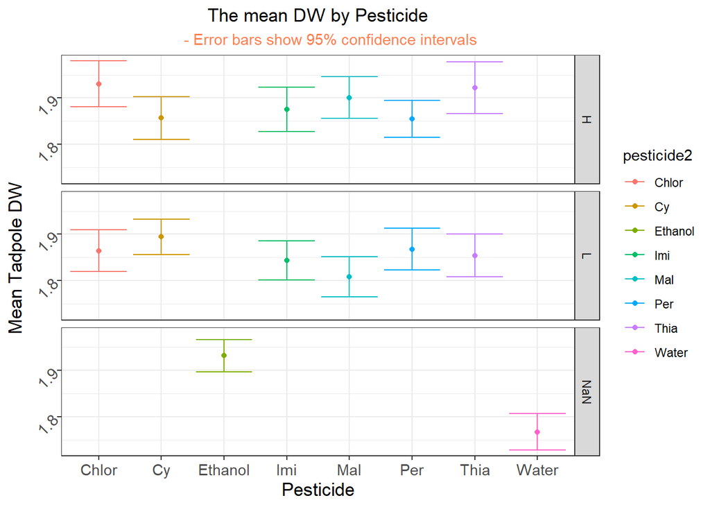

```r
DW_exp1 = experiment1%>%
  group_by(pesticidecon,pesticide2)%>%
  summarise(count = n(),  #  calculate count, mean, and sd in each group
             mean = mean(dw,na.rm=TRUE),
             std_dev = sd(dw,na.rm =TRUE ))%>%
   mutate(std_error = std_dev / sqrt(count),  #  add standard error of each mean
         lower = mean - 1.96 * std_error,  #  compute lower bound
          upper = mean + 1.96 * std_error)


ggplot(DW_exp1,aes(x=pesticide2,y=mean,col=pesticide2))+
  geom_point()+
  geom_errorbar(aes(ymin = lower,
                    ymax=upper))+
  labs(x="Pesticide",
       y="Mean Tadpole DW ",
       title = "The mean DW by Pesticide",
       subtitle = "      - Error bars show 95% confidence intervals")+
  my_theme+
  facet_grid(pesticidecon~.)
```

### Post Hoc of DW on Pesticide

```r
test_posthoc_exp1 <-experiment1%>%
  tukey_hsd(dw~pesticide2)

test_posthoc_exp1[which(test_posthoc_exp1$p.adj<=0.05),]%>%
  pander()
```

Table continues below

| term | group1 | group2 | estimate | conf.low | conf.high | p.adj |
| --- | --- | --- | --- | --- | --- | --- |
| pesticide2 | Chlor | Water | -0.1241 | -0.2267 | -0.02146 | 0.00627 |
| pesticide2 | Cy | Water | -0.1072 | -0.2098 | -0.004632 | 0.0333 |
| pesticide2 | Ethanol | Water | -0.1647 | -0.2829 | -0.04646 | 0.000704 |
| pesticide2 | Thia | Water | -0.1232 | -0.2262 | -0.02009 | 0.00734 |

| p.adj.signif |
| --- |
| ** |
| * |
| *** |
| ** |

This chunk performed a Tukey-test on pesticide category in terms of mean DW. The pairs with p-value <= 0.05 are shown

### Visualization of Pesticide DW

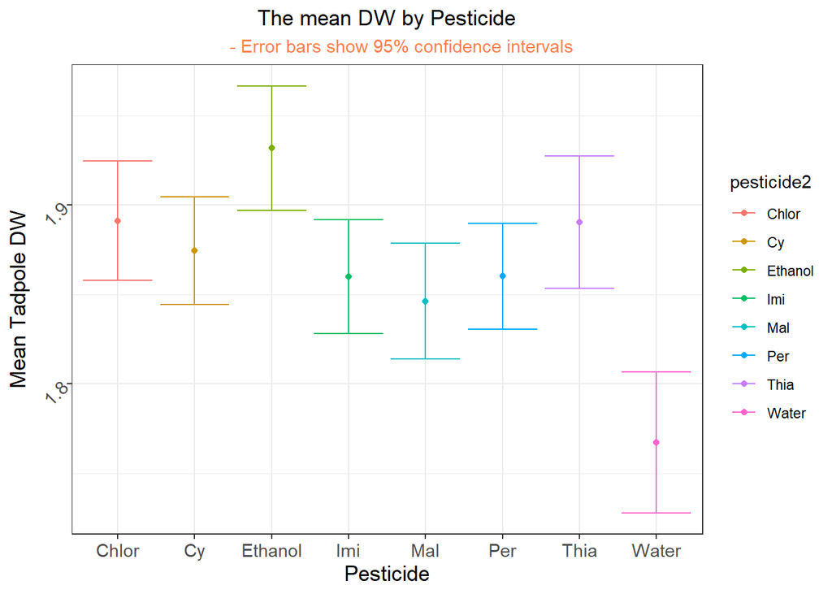

```r
DW_Pesti_exp1 = experiment1%>%
  group_by(pesticide2)%>%
  summarise(count = n(),  #  calculate count, mean, and sd in each group
             mean = mean(dw,na.rm=TRUE),
             std_dev = sd(dw,na.rm =TRUE ))%>%
   mutate(std_error = std_dev / sqrt(count),  #  add standard error of each mean
         lower = mean - 1.96 * std_error,  #  compute lower bound
          upper = mean + 1.96 * std_error)

ggplot(DW_Pesti_exp1,aes(x=pesticide2,y=mean,col=pesticide2))+
  geom_point()+
  geom_errorbar(aes(ymin = lower,
                    ymax=upper))+
  labs(x="Pesticide",
       y="Mean Tadpole DW",
       title = "The mean DW by Pesticide",
       subtitle = "      - Error bars show 95% confidence intervals")+
  my_theme
```

#### Post hoc DW on Concentration

```r
test_posthoc_exp1 <-experiment1%>%
  tukey_hsd(dw~pesticidecon)

test_posthoc_exp1[which(test_posthoc_exp1$p.adj<=0.05),]%>%
  pander()
```

Table continues below

| **term** | **group1** | **group2** | **estimate** | **conf.low** |
| --- | --- | --- | --- | --- |

| **conf.high** | **p.adj** | **p.adj.signif** |
| --- | --- | --- |

This chunk performed a Tukey-test on pesticide concentration in terms of mean DW. The pairs with p-value <= 0.05 is shown

### Visualization for concentration

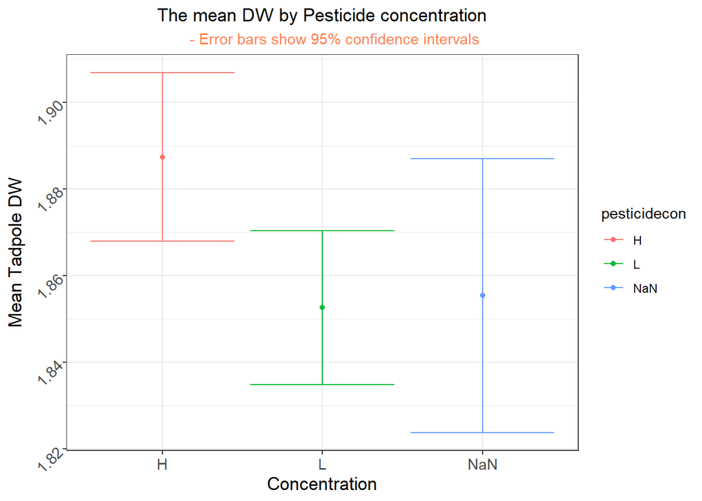

```r
DW_con_exp1 = experiment1%>%
  group_by(pesticidecon)%>%
  summarise(count = n(),  #  calculate count, mean, and sd in each group
             mean = mean(dw,na.rm=TRUE),
             std_dev = sd(dw,na.rm =TRUE ))%>%
   mutate(std_error = std_dev / sqrt(count),  #  add standard error of each mean
         lower = mean - 1.96 * std_error,  #  compute lower bound
          upper = mean + 1.96 * std_error)

ggplot(DW_con_exp1,aes(x=pesticidecon,y=mean,col=pesticidecon))+
  geom_point()+
  geom_errorbar(aes(ymin = lower,
                    ymax=upper))+
  labs(x="Concentration",
       y="Mean Tadpole DW",
       title = "The mean DW by Pesticide concentration",
       subtitle = "      - Error bars show 95% confidence intervals")+
  my_theme
```

### Two way ANOVA for DL

```r
experiment1%>%
  anova_test(dl~pesticide2 * pesticidecon)%>%
  pander()
```

| Effect | DFn | DFd | F | p | p<.05 | ges |
| --- | --- | --- | --- | --- | --- | --- |
| pesticide2 | 6 | 437 | 5.16 | 3.85e-05 | * | 0.066 |
| pesticidecon | 1 | 437 | 5.212 | 0.023 | * | 0.012 |
| pesticide2:pesticidecon | 5 | 437 | 2.638 | 0.023 | * | 0.029 |

#### Post hoc for DL

```r
experiment1%>%
  group_by(pesticidecon)%>%
  anova_test(dl~pesticide2)%>%
  pander()
```

| pesticidecon | Effect | DFn | DFd | F | p | p<.05 | ges |
| --- | --- | --- | --- | --- | --- | --- | --- |
| H | pesticide2 | 5 | 191 | 0.555 | 0.735 |  | 0.014 |
| L | pesticide2 | 5 | 192 | 8.185 | 5.01e-07 | * | 0.176 |
| NaN | pesticide2 | 1 | 54 | 0.023 | 0.881 |  | 0.000419 |

```r
test_posthoc_exp1 <-experiment1%>%
  group_by(pesticidecon)%>%
  tukey_hsd(dl~pesticide2)


test_posthoc_exp1[which(test_posthoc_exp1$p.adj<=0.05),]%>%
  pander()
```

Table continues below

| pesticidecon | term | group1 | group2 | estimate | conf.low | conf.high |
| --- | --- | --- | --- | --- | --- | --- |
| L | pesticide2 | Chlor | Cy | 0.1648 | 0.04748 | 0.2821 |
| L | pesticide2 | Chlor | Imi | 0.1948 | 0.0842 | 0.3053 |
| L | pesticide2 | Cy | Mal | -0.1446 | -0.2613 | -0.02795 |
| L | pesticide2 | Imi | Mal | -0.1746 | -0.2845 | -0.06471 |
| L | pesticide2 | Imi | Per | -0.1383 | -0.2629 | -0.01378 |
| L | pesticide2 | Imi | Thia | -0.1532 | -0.2725 | -0.03382 |

| p.adj | p.adj.signif |
| --- | --- |
| 0.00106 | ** |
| 1.37e-05 | **** |
| 0.00597 | ** |
| 0.000124 | *** |
| 0.0199 | * |
| 0.00385 | ** |

This chunk performed one way ANOVA of pesticide category in terms of mean DL by each concentration level and a Tukey-test on pesticide category in terms of mean DL. The pairs with p-value <= 0.05 are shown

### Visualization for DL

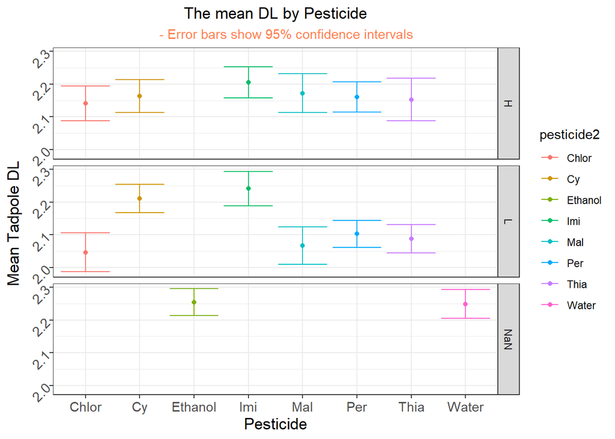

```r
DL_exp1 = experiment1%>%
  group_by(pesticidecon,pesticide2)%>%
  summarise(count = n(),  #  calculate count, mean, and sd in each group
             mean = mean(dl,na.rm=TRUE),
             std_dev = sd(dl,na.rm =TRUE ))%>%
   mutate(std_error = std_dev / sqrt(count),  #  add standard error of each mean
         lower = mean - 1.96 * std_error,  #  compute lower bound
          upper = mean + 1.96 * std_error)


ggplot(DL_exp1,aes(x=pesticide2,y=mean,col=pesticide2))+
  geom_point()+
  geom_errorbar(aes(ymin = lower,
                    ymax=upper))+
  labs(x="Pesticide",
       y="Mean Tadpole DL ",
       title = "The mean DL by Pesticide",
       subtitle = "      - Error bars show 95% confidence intervals")+
  my_theme+
  facet_grid(pesticidecon~.)
```

## Conclusion

1. Different pesticides have different effects on different brain dimensions
2. Ethanol generally associates a significantly larger brain measurement than water

# Experiment 2

## Three Way ANOVA on Body Mass

```r
experiment2%>%
  anova_test(bodymass~pesticide2 * pesticidecon*salt)
```

```
## ANOVA Table (type II tests)
##
##                         Effect DFn  DFd     F        p p<.05      ges
## 1                   pesticide2   4 1161 2.593 0.035000     * 9.00e-03
## 2                 pesticidecon   1 1161 0.047 0.828000       4.06e-05
## 3                         salt   2 1161 8.446 0.000228     * 1.40e-02
## 4      pesticide2:pesticidecon   3 1161 3.021 0.029000     * 8.00e-03
## 5              pesticide2:salt   8 1161 3.006 0.002000     * 2.00e-02
## 6            pesticidecon:salt   2 1161 4.173 0.016000     * 7.00e-03
## 7 pesticide2:pesticidecon:salt   6 1161 2.873 0.009000     * 1.50e-02
```

The interaction is significant

### Post Hoc for Bodymass

```r
experiment2%>%
  group_by(salt)%>%
  anova_test(bodymass~pesticide2*pesticidecon)%>%
  pander()
```

| salt | Effect | DFn | DFd | F | p | p<.05 | ges |
| --- | --- | --- | --- | --- | --- | --- | --- |
| H | pesticide2 | 4 | 385 | 1.809 | 0.126 |  | 0.018 |
| H | pesticidecon | 1 | 385 | 3.542 | 0.061 |  | 0.009 |
| H | pesticide2:pesticidecon | 3 | 385 | 1.401 | 0.242 |  | 0.011 |
| L | pesticide2 | 4 | 389 | 4.244 | 0.002 | * | 0.042 |
| L | pesticidecon | 1 | 389 | 0.025 | 0.873 |  | 6.55e-05 |
| L | pesticide2:pesticidecon | 3 | 389 | 6.451 | 0.000285 | * | 0.047 |
| N | pesticide2 | 4 | 387 | 2.57 | 0.038 | * | 0.026 |
| N | pesticidecon | 1 | 387 | 4.929 | 0.027 | * | 0.013 |
| N | pesticide2:pesticidecon | 3 | 387 | 0.819 | 0.484 |  | 0.006 |

1. The interaction is significant at salt level low
2. Only look at the test for salt level low

```r
post_hoc2 = experiment2%>%
  group_by(salt,pesticidecon)%>%
  anova_test(bodymass~pesticide2)

post_hoc2%>%
  pander()
```

| pesticidecon | salt | Effect | DFn | DFd | F | p | p<.05 | ges |
| --- | --- | --- | --- | --- | --- | --- | --- | --- |
| H | H | pesticide2 | 3 | 156 | 2.427 | 0.068 |  | 0.045 |
| L | H | pesticide2 | 3 | 153 | 0.108 | 0.955 |  | 0.002 |
| NaN | H | pesticide2 | 1 | 76 | 4.644 | 0.034 | * | 0.058 |
| H | L | pesticide2 | 3 | 156 | 5.394 | 0.001 | * | 0.094 |
| L | L | pesticide2 | 3 | 155 | 6.636 | 0.000302 | * | 0.114 |
| NaN | L | pesticide2 | 1 | 78 | 2.219 | 0.14 |  | 0.028 |
| H | N | pesticide2 | 3 | 153 | 0.68 | 0.565 |  | 0.013 |
| L | N | pesticide2 | 3 | 156 | 3.582 | 0.015 | * | 0.064 |
| NaN | N | pesticide2 | 1 | 78 | 0.019 | 0.892 |  | 0.000238 |

```r
Tukey_L = experiment2%>%
  group_by(salt,pesticidecon)%>%
  tukey_hsd(bodymass~pesticide2)

Result_H = Tukey_L%>% filter(salt == "L",pesticidecon=="H")

Result_L = Tukey_L%>% filter(salt == "L",pesticidecon=="L")

Result_H[which(Result_H$p.adj<=0.05),]%>%
  pander()
```

Table continues below

| pesticidecon | salt | term | group1 | group2 | estimate | conf.low |
| --- | --- | --- | --- | --- | --- | --- |
| H | L | pesticide2 | Chlor | Mal | 0.3704 | 0.07798 |
| H | L | pesticide2 | Mal | Per | -0.3559 | -0.6483 |

| conf.high | p.adj | p.adj.signif |
| --- | --- | --- |
| 0.6628 | 0.00674 | ** |
| -0.06353 | 0.0101 | * |

```r
Result_L[which(Result_L$p.adj<=0.05),]%>%
  pander()
```

Table continues below

| pesticidecon | salt | term | group1 | group2 | estimate | conf.low |
| --- | --- | --- | --- | --- | --- | --- |
| L | L | pesticide2 | Chlor | Per | 0.4871 | 0.1827 |
| L | L | pesticide2 | Mal | Per | 0.378 | 0.07169 |

| conf.high | p.adj | p.adj.signif |
| --- | --- | --- |
| 0.7915 | 0.000309 | *** |
| 0.6844 | 0.00882 | ** |

This chunk performed an one way ANOVA of pesticide category in terms of mean body mass by each concentration level and salt level and a Tukey-test on pesticide category in terms of mean body mass. The pairs with p-value <= 0.05 are shown

### Visualization

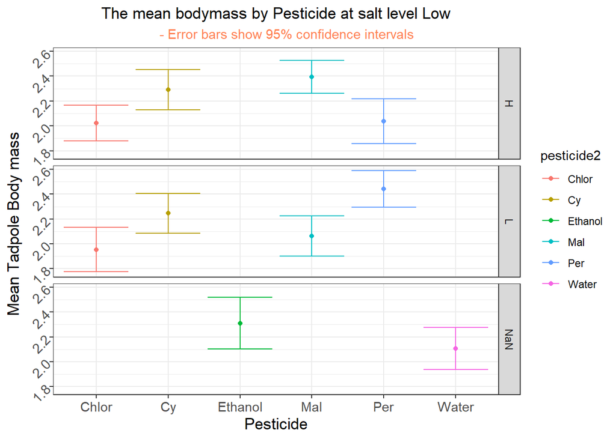

```r
Exp2_SaltL = subset(experiment2,experiment2$salt=="L")
Exp2_SaltH = subset(experiment2,experiment2$salt=="H")
Exp2_SaltN = subset(experiment2,experiment2$salt=="N")

Bodymass_exp2 = Exp2_SaltL%>%
  group_by(pesticidecon,pesticide2)%>%
  summarise(count = n(),  #  calculate count, mean, and sd in each group
             mean = mean(bodymass,na.rm=TRUE),
             std_dev = sd(bodymass,na.rm =TRUE ))%>%
   mutate(std_error = std_dev / sqrt(count),  #  add standard error of each mean
         lower = mean - 1.96 * std_error,  #  compute lower bound
          upper = mean + 1.96 * std_error)


ggplot(Bodymass_exp2,aes(x=pesticide2,y=mean,col=pesticide2))+
  geom_point()+
  geom_errorbar(aes(ymin = lower,
                    ymax=upper))+
  labs(x="Pesticide",
       y="Mean Tadpole Body mass ",
       title = "The mean bodymass by Pesticide at salt level Low",
       subtitle = "      - Error bars show 95% confidence intervals")+
  my_theme+
  facet_grid(pesticidecon~.)
```

## MANOVA for experiment 2

```r
manova(cbind(tw,tl,dw,dl,otw,otl,obl,mw)~pesticide2 * pesticidecon*salt,data=experiment2)%>%
  pander()
```

Table continues below

|  | Df | Pillai | approx F | num Df | den Df |
| --- | --- | --- | --- | --- | --- |
| **pesticide2** | 5 | 0.1906 | 4.816 | 40 | 4860 |
| **pesticidecon** | 1 | 0.03327 | 4.164 | 8 | 968 |
| **salt** | 2 | 0.1313 | 8.509 | 16 | 1938 |
| **pesticide2:pesticidecon** | 3 | 0.08973 | 3.738 | 24 | 2910 |
| **pesticide2:salt** | 10 | 0.3273 | 4.159 | 80 | 7800 |
| **pesticidecon:salt** | 2 | 0.03177 | 1.955 | 16 | 1938 |
| **pesticide2:pesticidecon:salt** | 6 | 0.169 | 3.525 | 48 | 5838 |
| **Residuals** | 975 | NA | NA | NA | NA |

|  | Pr(>F) |
| --- | --- |
| **pesticide2** | 2.461e-21 |
| **pesticidecon** | 6.552e-05 |
| **salt** | 2.568e-20 |
| **pesticide2:pesticidecon** | 2.363e-09 |
| **pesticide2:salt** | 1.147e-31 |
| **pesticidecon:salt** | 0.01289 |
| **pesticide2:pesticidecon:salt** | 3.864e-15 |
| **Residuals** | NA |

### Three way ANOVA on MW

```r
experiment2%>%
  anova_test(mw~pesticide2 * pesticidecon*salt)
```

```
## ANOVA Table (type II tests)
##
##                         Effect DFn DFd      F        p p<.05   ges
## 1                   pesticide2   4 999  3.520 7.00e-03     * 0.014
## 2                 pesticidecon   1 999  4.549 3.30e-02     * 0.005
## 3                         salt   2 999 13.902 1.11e-06     * 0.027
## 4      pesticide2:pesticidecon   3 999 12.694 3.80e-08     * 0.037
## 5              pesticide2:salt   8 999  7.434 1.18e-09     * 0.056
## 6            pesticidecon:salt   2 999  1.213 2.98e-01       0.002
## 7 pesticide2:pesticidecon:salt   6 999  3.268 3.00e-03     * 0.019
```

Interaction is significant

```r
experiment2%>%
  group_by(salt)%>%
  anova_test(mw~pesticide2*pesticidecon)%>%
  pander()
```

| salt | Effect | DFn | DFd | F | p | p<.05 | ges |
| --- | --- | --- | --- | --- | --- | --- | --- |
| H | pesticide2 | 4 | 350 | 6.766 | 2.96e-05 | * | 0.072 |
| H | pesticidecon | 1 | 350 | 1.165 | 0.281 |  | 0.003 |
| H | pesticide2:pesticidecon | 3 | 350 | 6.668 | 0.000217 | * | 0.054 |
| L | pesticide2 | 4 | 343 | 2.431 | 0.047 | * | 0.028 |
| L | pesticidecon | 1 | 343 | 0.107 | 0.744 |  | 0.000311 |
| L | pesticide2:pesticidecon | 3 | 343 | 5.823 | 0.000686 | * | 0.048 |
| N | pesticide2 | 4 | 306 | 10.5 | 5.53e-08 | * | 0.121 |
| N | pesticidecon | 1 | 306 | 5.81 | 0.017 | * | 0.019 |
| N | pesticide2:pesticidecon | 3 | 306 | 6.877 | 0.00017 | * | 0.063 |

This chunk performed an two way ANOVA of pesticide category in terms of mean MW by each salt level

```r
Tukey_SL = experiment2%>%
  group_by(salt,pesticidecon)%>%
  tukey_hsd(mw~pesticide2)

Tukey_SL[which(Tukey_SL$p.adj<=0.05),]%>%
  pander()
```

Table continues below

| pesticidecon | salt | term | group1 | group2 | estimate | conf.low |
| --- | --- | --- | --- | --- | --- | --- |
| H | H | pesticide2 | Chlor | Cy | -0.08974 | -0.1711 |
| H | H | pesticide2 | Chlor | Mal | -0.1011 | -0.183 |
| L | H | pesticide2 | Chlor | Cy | 0.1235 | 0.01907 |
| L | H | pesticide2 | Cy | Mal | -0.1699 | -0.2693 |
| L | H | pesticide2 | Mal | Per | 0.1493 | 0.04542 |
| NaN | H | pesticide2 | Ethanol | Water | 0.09404 | 0.01293 |
| L | L | pesticide2 | Chlor | Mal | -0.08673 | -0.171 |
| L | L | pesticide2 | Mal | Per | 0.1586 | 0.07437 |
| L | N | pesticide2 | Chlor | Cy | 0.1449 | 0.04677 |
| L | N | pesticide2 | Cy | Mal | -0.129 | -0.2266 |
| L | N | pesticide2 | Cy | Per | -0.1497 | -0.2591 |
| NaN | N | pesticide2 | Ethanol | Water | -0.2339 | -0.3065 |

| conf.high | p.adj | p.adj.signif |
| --- | --- | --- |
| -0.008348 | 0.0244 | * |
| -0.01915 | 0.00885 | ** |
| 0.2278 | 0.0134 | * |
| -0.07054 | 0.000106 | *** |
| 0.2531 | 0.00154 | ** |
| 0.1751 | 0.0237 | * |
| -0.002466 | 0.0411 | * |
| 0.2429 | 1.66e-05 | **** |
| 0.2431 | 0.00108 | ** |
| -0.03135 | 0.00432 | ** |
| -0.04024 | 0.00289 | ** |
| -0.1612 | 3.15e-08 | **** |

This chunk performed an one way ANOVA of pesticide category in terms of mean MW by each concentration level and salt level and a Tukey-test on pesticide category in terms of mean MW. The pairs with p-value <= 0.05 are shown

### Visualization salt H

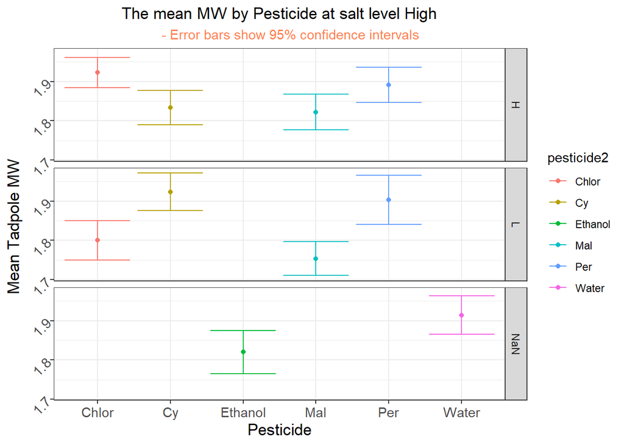

```r
MW_exp2 = Exp2_SaltH%>%
  group_by(pesticidecon,pesticide2)%>%
  summarise(count = n(),  #  calculate count, mean, and sd in each group
             mean = mean(mw,na.rm=TRUE),
             std_dev = sd(mw,na.rm =TRUE ))%>%
   mutate(std_error = std_dev / sqrt(count),  #  add standard error of each mean
         lower = mean - 1.96 * std_error,  #  compute lower bound
          upper = mean + 1.96 * std_error)


ggplot(MW_exp2,aes(x=pesticide2,y=mean,col=pesticide2))+
  geom_point()+
  geom_errorbar(aes(ymin = lower,
                    ymax=upper))+
  labs(x="Pesticide",
       y="Mean Tadpole MW ",
       title = "The mean MW by Pesticide at salt level High",
       subtitle = "      - Error bars show 95% confidence intervals")+
  my_theme+
  facet_grid(pesticidecon~.)
```

### visualization salt L

```r
MW_exp2 = Exp2_SaltL%>%
  group_by(pesticidecon,pesticide2)%>%
  summarise(count = n(),  #  calculate count, mean, and sd in each group
             mean = mean(mw,na.rm=TRUE),
             std_dev = sd(mw,na.rm =TRUE ))%>%
   mutate(std_error = std_dev / sqrt(count),  #  add standard error of each mean
         lower = mean - 1.96 * std_error,  #  compute lower bound
          upper = mean + 1.96 * std_error)
```

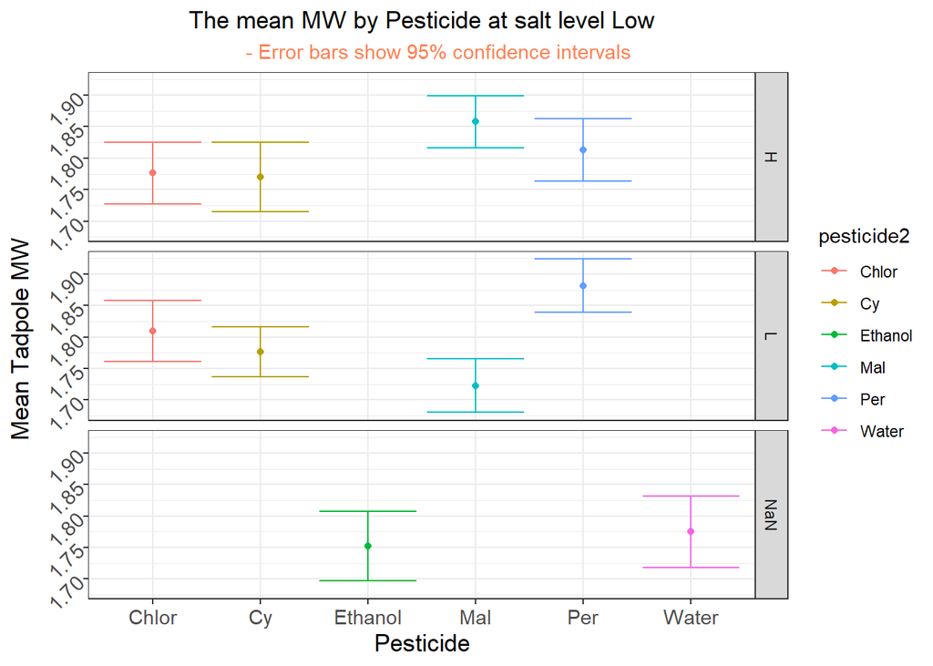

```r
ggplot(MW_exp2,aes(x=pesticide2,y=mean,col=pesticide2))+
  geom_point()+
  geom_errorbar(aes(ymin = lower,
                    ymax=upper))+
  labs(x="Pesticide",
       y="Mean Tadpole MW ",
       title = "The mean MW by Pesticide at salt level Low",
       subtitle = "      - Error bars show 95% confidence intervals")+
  my_theme+
  facet_grid(pesticidecon~.)
```

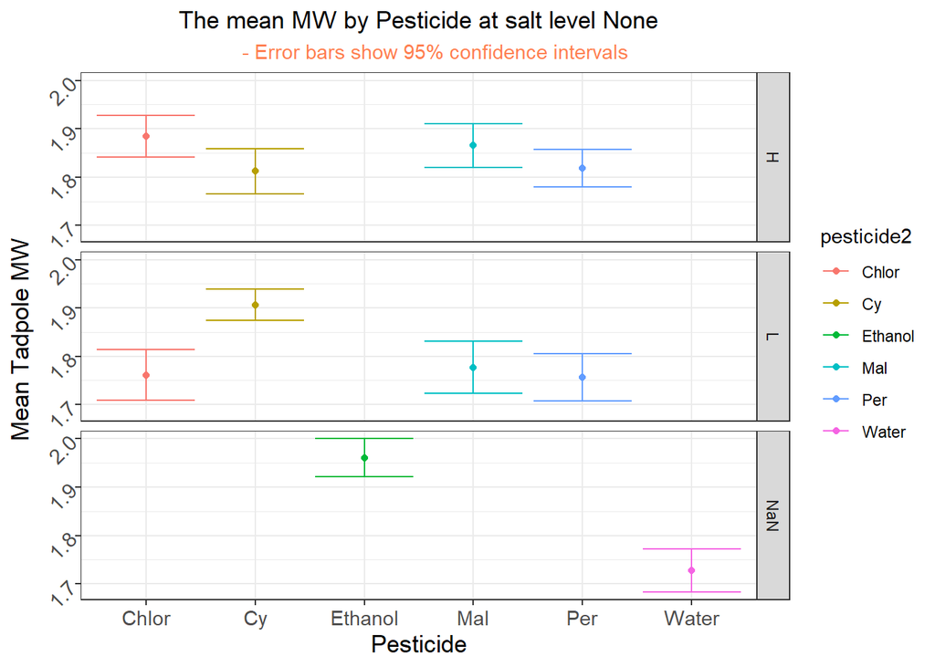

```r
MW_exp2 = Exp2_SaltN%>%
  group_by(pesticidecon,pesticide2)%>%
  summarise(count = n(),  #  calculate count, mean, and sd in each group
             mean = mean(mw,na.rm=TRUE),
             std_dev = sd(mw,na.rm =TRUE ))%>%
   mutate(std_error = std_dev / sqrt(count),  #  add standard error of each mean
         lower = mean - 1.96 * std_error,  #  compute lower bound
          upper = mean + 1.96 * std_error)


ggplot(MW_exp2,aes(x=pesticide2,y=mean,col=pesticide2))+
  geom_point()+
  geom_errorbar(aes(ymin = lower,
                    ymax=upper))+
  labs(x="Pesticide",
       y="Mean Tadpole MW ",
       title = "The mean MW by Pesticide at salt level None",
       subtitle = "      - Error bars show 95% confidence intervals")+
  my_theme+
  facet_grid(pesticidecon~.)
```

### Three Way ANOVA for TW

```r
experiment2%>%
  anova_test(tw~pesticide2 * pesticidecon*salt)
```

```
## ANOVA Table (type II tests)
##
##                         Effect DFn DFd     F     p p<.05   ges
## 1                   pesticide2   4 993 3.253 0.012     * 0.013
## 2                 pesticidecon   1 993 1.281 0.258       0.001
## 3                         salt   2 993 2.783 0.062       0.006
## 4      pesticide2:pesticidecon   3 993 4.206 0.006     * 0.013
## 5              pesticide2:salt   8 993 2.986 0.003     * 0.023
## 6            pesticidecon:salt   2 993 2.393 0.092       0.005
## 7 pesticide2:pesticidecon:salt   6 993 2.986 0.007     * 0.018
```

Interaction is significant

```r
experiment2%>%
  group_by(salt)%>%
  anova_test(tw~pesticide2*pesticidecon)%>%
  pander()
```

| salt | Effect | DFn | DFd | F | p | p<.05 | ges |
| --- | --- | --- | --- | --- | --- | --- | --- |
| H | pesticide2 | 4 | 349 | 2.617 | 0.035 | * | 0.029 |
| H | pesticidecon | 1 | 349 | 0.025 | 0.874 |  | 7.26e-05 |
| H | pesticide2:pesticidecon | 3 | 349 | 1.356 | 0.256 |  | 0.012 |
| L | pesticide2 | 4 | 340 | 2.317 | 0.057 |  | 0.027 |
| L | pesticidecon | 1 | 340 | 0.052 | 0.82 |  | 0.000152 |
| L | pesticide2:pesticidecon | 3 | 340 | 4.217 | 0.006 | * | 0.036 |
| N | pesticide2 | 4 | 304 | 4.753 | 0.000984 | * | 0.059 |
| N | pesticidecon | 1 | 304 | 6.524 | 0.011 | * | 0.021 |
| N | pesticide2:pesticidecon | 3 | 304 | 4.723 | 0.003 | * | 0.045 |

This chunk performed an two way ANOVA of pesticide category in terms of mean TW by each salt level

Interaction is significant on salt level L and N

```r
experiment2%>%
  group_by(salt,pesticidecon)%>%
  anova_test(tw~pesticide2)%>%
  pander()
```

[output not shown]

[output not shown]

[output not shown]

[output not shown]

[output not shown]

[output not shown]

[output not shown]

[output not shown]

[output not shown]

| pesticidecon | salt | Effect | DFn | DFd | F | p | p<.05 | ges |
| --- | --- | --- | --- | --- | --- | --- | --- | --- |
| H | H | pesticide2 | 3 | 152 | 4.036 | 0.009 | * | 0.074 |
| L | H | pesticide2 | 3 | 132 | 0.804 | 0.494 |  | 0.018 |
| NaN | H | pesticide2 | 1 | 65 | 1.939 | 0.169 |  | 0.029 |
| H | L | pesticide2 | 3 | 136 | 2.866 | 0.039 | * | 0.059 |
| L | L | pesticide2 | 3 | 129 | 4.775 | 0.003 | * | 0.1 |
| NaN | L | pesticide2 | 1 | 75 | 0.13 | 0.72 |  | 0.002 |
| H | N | pesticide2 | 3 | 121 | 1.581 | 0.198 |  | 0.038 |
| L | N | pesticide2 | 3 | 129 | 4.152 | 0.008 | * | 0.088 |
| NaN | N | pesticide2 | 1 | 54 | 16.93 | 0.000133 | * | 0.239 |

```r
Tukey_SL = experiment2%>%
  group_by(salt,pesticidecon)%>%
  tukey_hsd(tw~pesticide2)

Tukey_SLL=Tukey_SL%>%filter(salt=="L")

Tukey_SLL[which(Tukey_SLL$p.adj<=0.05),]%>%
  pander()
```

Table continues below

| pesticidecon | salt | term | group1 | group2 | estimate | conf.low |
| --- | --- | --- | --- | --- | --- | --- |
| L | L | pesticide2 | Mal | Per | 0.117 | 0.0337 |

| conf.high | p.adj | p.adj.signif |
| --- | --- | --- |
| 0.2004 | 0.00209 | ** |

```r
Tukey_SN=Tukey_SL%>%filter(salt=="N")

Tukey_SN[which(Tukey_SN$p.adj<=0.05),]%>%
  pander()
```

Table continues below

| pesticidecon | salt | term | group1 | group2 | estimate | conf.low |
| --- | --- | --- | --- | --- | --- | --- |
| L | N | pesticide2 | Cy | Mal | -0.1063 | -0.192 |
| NaN | N | pesticide2 | Ethanol | Water | -0.1374 | -0.2044 |

| conf.high | p.adj | p.adj.signif |
| --- | --- | --- |
| -0.02057 | 0.0085 | ** |
| -0.07047 | 0.000133 | *** |

### Visualization

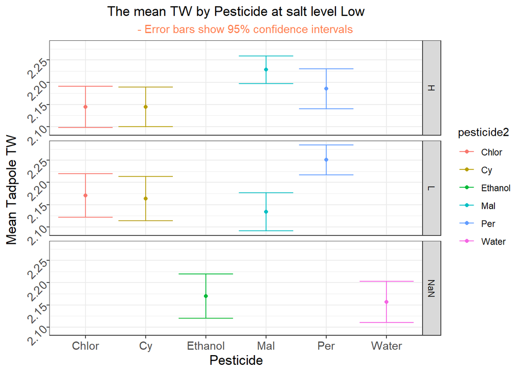

```r
TW_exp2 = Exp2_SaltL%>%
  group_by(pesticidecon,pesticide2)%>%
  summarise(count = n(),  #  calculate count, mean, and sd in each group
             mean = mean(tw,na.rm=TRUE),
             std_dev = sd(tw,na.rm =TRUE ))%>%
   mutate(std_error = std_dev / sqrt(count),  #  add standard error of each mean
         lower = mean - 1.96 * std_error,  #  compute lower bound
          upper = mean + 1.96 * std_error)


ggplot(TW_exp2,aes(x=pesticide2,y=mean,col=pesticide2))+
  geom_point()+
  geom_errorbar(aes(ymin = lower,
                    ymax=upper))+
  labs(x="Pesticide",
       y="Mean Tadpole TW ",
       title = "The mean TW by Pesticide at salt level Low",
       subtitle = "      - Error bars show 95% confidence intervals")+
  my_theme+
  facet_grid(pesticidecon~.)
```

[figure not shown]

```r
TW_exp2 = Exp2_SaltN%>%
  group_by(pesticidecon,pesticide2)%>%
  summarise(count = n(),  #  calculate count, mean, and sd in each group
             mean = mean(tw,na.rm=TRUE),
             std_dev = sd(tw,na.rm =TRUE ))%>%
   mutate(std_error = std_dev / sqrt(count),  #  add standard error of each mean
         lower = mean - 1.96 * std_error,  #  compute lower bound
          upper = mean + 1.96 * std_error)


ggplot(TW_exp2,aes(x=pesticide2,y=mean,col=pesticide2))+
  geom_point()+
  geom_errorbar(aes(ymin = lower,
                    ymax=upper))+
  labs(x="Pesticide",
       y="Mean Tadpole TW ",
       title = "The mean TW by Pesticide at salt level Low",
       subtitle = "      - Error bars show 95% confidence intervals")+
  my_theme+
  facet_grid(pesticidecon~.)
```

### Three Way ANOVA for TL

```r
experiment2%>%
  anova_test(tl~pesticide2 * pesticidecon*salt)
```

```
## ANOVA Table (type II tests)
##
##                         Effect DFn DFd     F        p p<.05      ges
## 1                   pesticide2   4 997 3.076 0.016000     * 0.012000
## 2                 pesticidecon   1 997 0.682 0.409000       0.000684
## 3                         salt   2 997 7.130 0.000842     * 0.014000
## 4      pesticide2:pesticidecon   3 997 5.364 0.001000     * 0.016000
## 5              pesticide2:salt   8 997 0.478 0.872000       0.004000
## 6            pesticidecon:salt   2 997 0.163 0.849000       0.000327
## 7 pesticide2:pesticidecon:salt   6 997 2.464 0.023000     * 0.015000
```

Interaction is significant

```r
experiment2%>%
  group_by(salt)%>%
  anova_test(tl~pesticide2*pesticidecon)%>%
  pander()
```

| salt | Effect | DFn | DFd | F | p | p<.05 | ges |
| --- | --- | --- | --- | --- | --- | --- | --- |
| H | pesticide2 | 4 | 350 | 1.05 | 0.381 |  | 0.012 |
| H | pesticidecon | 1 | 350 | 0.658 | 0.418 |  | 0.002 |
| H | pesticide2:pesticidecon | 3 | 350 | 0.43 | 0.732 |  | 0.004 |
| L | pesticide2 | 4 | 341 | 1.467 | 0.212 |  | 0.017 |
| L | pesticidecon | 1 | 341 | 0.086 | 0.77 |  | 0.000251 |
| L | pesticide2:pesticidecon | 3 | 341 | 6.249 | 0.000386 | * | 0.052 |
| N | pesticide2 | 4 | 306 | 1.576 | 0.18 |  | 0.02 |
| N | pesticidecon | 1 | 306 | 0.08 | 0.777 |  | 0.000263 |
| N | pesticide2:pesticidecon | 3 | 306 | 4.045 | 0.008 | * | 0.038 |

This chunk performed a two way ANOVA of pesticide category and concentration in terms of mean TL by each salt level

Interaction is significant on salt level low and none

```r
Tukey_SL = experiment2%>%
  group_by(salt,pesticidecon)%>%
  tukey_hsd(tl~pesticide2)

Tukey_SLL=Tukey_SL%>%filter(salt=="L")

Tukey_SLL[which(Tukey_SLL$p.adj<=0.05),]%>%
  pander()
```

Table continues below

| pesticidecon | salt | term | group1 | group2 | estimate | conf.low |
| --- | --- | --- | --- | --- | --- | --- |
| H | L | pesticide2 | Cy | Mal | 0.1172 | 0.01351 |
| L | L | pesticide2 | Chlor | Cy | 0.1419 | 0.008196 |
| L | L | pesticide2 | Chlor | Per | 0.1108 | 0.00457 |
| L | L | pesticide2 | Cy | Mal | -0.1525 | -0.2867 |
| L | L | pesticide2 | Mal | Per | 0.1214 | 0.01443 |

| conf.high | p.adj | p.adj.signif |
| --- | --- | --- |
| 0.221 | 0.0199 | * |
| 0.2756 | 0.0329 | * |
| 0.2171 | 0.0374 | * |
| -0.0182 | 0.0192 | * |
| 0.2283 | 0.0193 | * |

```r
Tukey_SN=Tukey_SL%>%filter(salt=="N")

Tukey_SN[which(Tukey_SN$p.adj<=0.05),]%>%
  pander()
```

Table continues below

| pesticidecon | salt | term | group1 | group2 | estimate | conf.low |
| --- | --- | --- | --- | --- | --- | --- |
| L | N | pesticide2 | Chlor | Per | 0.1292 | 0.01231 |
| L | N | pesticide2 | Mal | Per | 0.1694 | 0.05314 |

| conf.high | p.adj | p.adj.signif |
| --- | --- | --- |
| 0.246 | 0.024 | * |
| 0.2857 | 0.00129 | ** |

This chunk performed a Tukey-test on pesticide category in terms of mean TL by each concentration level and salt level. The pairs with p-value <= 0.05 are shown. (I did not write down the ANOVA test because a non-empty result from tukey test implies a statistically significant result in the one way ANOVA test)